# Actuarial Data Science Immersion - Part I

Chow Chun Mun

13-05-2025

The following code assumes that the `renv` package has been installed in the global environment and that an R project has been created using `renv`. Moreover, the package versions have been updated and locked using `renv::snapshot()`.

# 1 Introduction

The goal of Part I is to analyze the dataset `diabetic data.csv`, which contains hospital records of diabetes patients and specifically investigates factors contributing to early readmissions within 30 days. Early readmissions serve as indicators of treatment quality and preventability, and they lead to additional costs for health insurance providers. Following data preprocessing, an exploratory data analysis (EDA) will be conducted, along with the development of initial machine learning models, first for binary classification, and finally for ternary classification in the last task. Additional background information is provided in the accompanying scientific paper (*paper.pdf*), which describes the dataset and its clinical context.

# 2 Task R0: Libraries, Reproducibility, and Core Helper Functions

At this point, load all packages required for the subsequent tasks. Ensure that you load only those packages that are actually needed and used to maintain the efficiency and readability of the notebook. Additionally, ensure the reproducibility of the notebook. Define core helper functions as well; specifically, incorporate the functions `multiplot` and `get_binCI` from the SWoF template to generate multiple plots and compute binomial confidence intervals.

**Solution:**

## 2.1 Reproducibility

We set a seed to ensure reproducibility across all random processes (e.g., sampling, model training). Optionally, a `renv.lock` file can be provided upon request to allow others to recreate the exact package environment used in this project using `renv::restore()`.

```r
# Set the seed for reproducibility
seed <- 4321
set.seed(seed)
```

## 2.2 Load libraries

We load a range of libraries for general data wrangling and general visualisation together with more specialised tools.

```r
# general visualisation
library(ggplot2) # visualisation
library(corrplot) # visualisation
library(grid) # visualisation

# general data manipulation
library(dplyr) # data manipulation
library(readr) # input/output
library(data.table) # data manipulation
library(tibble) # data wrangling
library(tidyr) # data wrangling

# modelling
library(xgboost) # modelling
library(caret) # modelling
library(nnet) # modelling
library(MLmetrics) # gini metric
library(hstats) # interaction evaluation
library(glmnet) # modelling
library(mgcv) # modelling

# Print version information about R, the OS and attached or loaded packages
```

## 2.3 Helper functions

We use the *multiplot* function, courtesy of R Cookbooks to create multi-panel plots. We also make use of a brief helper function to compute binomial confidence intervals.

```r
# Define multiple plot function
#
# ggplot objects can be passed in ..., or to plotlist (as a list of ggplot objects)
# - cols:   Number of columns in layout
# - layout: A matrix specifying the layout. If present, 'cols' is ignored.
#
# If the layout is something like matrix(c(1,2,3,3), nrow=2, byrow=TRUE),
# then plot 1 will go in the upper left, 2 will go in the upper right, and
# 3 will go all the way across the bottom.
#
multiplot <- function(..., plotlist=NULL, file, cols=1, layout=NULL) {

  # Make a list from the ... arguments and plotlist
  plots <- c(list(...), plotlist)

  numPlots = length(plots)

  # If layout is NULL, then use 'cols' to determine layout
  if (is.null(layout)) {
    # Make the panel
    # ncol: Number of columns of plots
    # nrow: Number of rows needed, calculated from # of cols
    layout <- matrix(seq(1, cols * ceiling(numPlots/cols)),
                    ncol = cols, nrow = ceiling(numPlots/cols))
  }

 if (numPlots==1) {
    print(plots[[1]])

  } else {
    # Set up the page
    grid.newpage()
    pushViewport(viewport(layout = grid.layout(nrow(layout), ncol(layout))))

    # Make each plot, in the correct location
    for (i in 1:numPlots) {
      # Get the i,j matrix positions of the regions that contain this subplot
      matchidx <- as.data.frame(which(layout == i, arr.ind = TRUE))

      print(plots[[i]], vp = viewport(layout.pos.row = matchidx$row,
                                      layout.pos.col = matchidx$col))
    }
  }
}
```

```r
# function to extract binomial confidence levels
get_binCI <- function(x,n) as.list(setNames(binom.test(x,n)$conf.int, c("lwr", "upr")))
```

# 3 Task R1: Data Preprocessing

This task focuses on reading, filtering, preparing, and exporting data. The aim is to perform basic preprocessing steps to prepare the main dataset for use as the foundation for the subsequent tasks in Part I as well as Part II.

## 3.1 a) Reading data

Load the file *diabetic data.csv* from the examination materials. Ensure that character strings are read as factors (data type: factor) and that missing values are not explicitly set using a `na.strings` statement. Output the number of rows and columns of the imported dataset, print the first ten entries, and verify the file is correctly imported. Briefly discuss one advantage and one disadvantage of the above approach to handling missing values in this dataset. Finally, check whether the dataset contains not only the values? but also other “real” missing values (NA).

**Solution:**

We use *data.table*’s `fread()` function to speed up data loading and set `stringsAsFactors = TRUE` to ensure that character strings are read as factors.

```r
# Load the data
diabetic_data <- as.tibble(fread('../01_raw_data/diabetic_data.csv', # UPDATE this path if needed
                                 stringsAsFactors = TRUE))

# Number of rows and columns of the imported dataset
dim(diabetic_data)
```

The dataset *diabetic data.csv* consists of 101766 rows and 50 columns in total. We output then the first ten entries of the dataset:

```r
# Print the first ten entries
head(diabetic_data, 10)
```

```
## # A tibble: 10 × 50
##    encounter_id patient_nbr race           gender age   weight admission_type_id
##           <int>       <int> <fct>          <fct>  <fct> <fct>              <int>
##  1      2278392     8222157 Caucasian      Female [0-1… ?                      6
##  2       149190    55629189 Caucasian      Female [10-… ?                      1
##  3        64410    86047875 AfricanAmeric… Female [20-… ?                      1
##  4       500364    82442376 Caucasian      Male   [30-… ?                      1
##  5        16680    42519267 Caucasian      Male   [40-… ?                      1
##  6        35754    82637451 Caucasian      Male   [50-… ?                      2
##  7        55842    84259809 Caucasian      Male   [60-… ?                      3
##  8        63768   114882984 Caucasian      Male   [70-… ?                      1
##  9        12522    48330783 Caucasian      Female [80-… ?                      2
## 10        15738    63555939 Caucasian      Female [90-… ?                      3
## # ℹ 43 more variables: discharge_disposition_id <int>,
## #   admission_source_id <int>, time_in_hospital <int>, payer_code <fct>,
## #   medical_specialty <fct>, num_lab_procedures <int>, num_procedures <int>,
## #   num_medications <int>, number_outpatient <int>, number_emergency <int>,
## #   number_inpatient <int>, diag_1 <fct>, diag_2 <fct>, diag_3 <fct>,
## #   number_diagnoses <int>, max_glu_serum <fct>, A1Cresult <fct>,
## #   metformin <fct>, repaglinide <fct>, nateglinide <fct>, …
```

Now, let’s have an overview of the data sets using the *summary* tool.

```r
# Brief overview of the feature values
summary(diabetic_data)
```

```
##   encounter_id        patient_nbr                     race
##  Min.   :    12522   Min.   :      135   ?              : 2273
##  1st Qu.: 84961194   1st Qu.: 23413221   AfricanAmerican:19210
##  Median :152388987   Median : 45505143   Asian          :  641
##  Mean   :165201646   Mean   : 54330401   Caucasian      :76099
##  3rd Qu.:230270888   3rd Qu.: 87545950   Hispanic       : 2037
##  Max.   :443867222   Max.   :189502619   Other          : 1506
##
##              gender           age              weight      admission_type_id
##  Female         :54708   [70-80):26068   ?        :98569   Min.   :1.000
##  Male           :47055   [60-70):22483   [75-100) : 1336   1st Qu.:1.000
##  Unknown/Invalid:    3   [50-60):17256   [50-75)  :  897   Median :1.000
##                          [80-90):17197   [100-125):  625   Mean   :2.024
##                          [40-50): 9685   [125-150):  145   3rd Qu.:3.000
##                          [30-40): 3775   [25-50)  :   97   Max.   :8.000
##                          (Other): 5302   (Other)  :   97
##  discharge_disposition_id admission_source_id time_in_hospital   payer_code
##  Min.   : 1.000           Min.   : 1.000      Min.   : 1.000   ?      :40256
##  1st Qu.: 1.000           1st Qu.: 1.000      1st Qu.: 2.000   MC     :32439
##  Median : 1.000           Median : 7.000      Median : 4.000   HM     : 6274
##  Mean   : 3.716           Mean   : 5.754      Mean   : 4.396   SP     : 5007
##  3rd Qu.: 4.000           3rd Qu.: 7.000      3rd Qu.: 6.000   BC     : 4655
##  Max.   :28.000           Max.   :25.000      Max.   :14.000   MD     : 3532
##                                                                (Other): 9603
##               medical_specialty num_lab_procedures num_procedures
##  ?                     :49949   Min.   :  1.0      Min.   :0.00
##  InternalMedicine      :14635   1st Qu.: 31.0      1st Qu.:0.00
##  Emergency/Trauma      : 7565   Median : 44.0      Median :1.00
##  Family/GeneralPractice: 7440   Mean   : 43.1      Mean   :1.34
##  Cardiology            : 5352   3rd Qu.: 57.0      3rd Qu.:2.00
##  Surgery-General       : 3099   Max.   :132.0      Max.   :6.00
##  (Other)               :13726
##  num_medications number_outpatient number_emergency  number_inpatient
##  Min.   : 1.00   Min.   : 0.0000   Min.   : 0.0000   Min.   : 0.0000
##  1st Qu.:10.00   1st Qu.: 0.0000   1st Qu.: 0.0000   1st Qu.: 0.0000
##  Median :15.00   Median : 0.0000   Median : 0.0000   Median : 0.0000
##  Mean   :16.02   Mean   : 0.3694   Mean   : 0.1978   Mean   : 0.6356
##  3rd Qu.:20.00   3rd Qu.: 0.0000   3rd Qu.: 0.0000   3rd Qu.: 1.0000
##  Max.   :81.00   Max.   :42.0000   Max.   :76.0000   Max.   :21.0000
##
```

[output cut: 41 more lines]

```
##  No    :101753       No    :101765            No    :101764
##  Steady:    13       Steady:     1            Steady:     2
##
##
##
##
##
##  metformin-pioglitazone change     diabetesMed readmitted
##  No    :101765          Ch:47011   No :23403   <30:11357
##  Steady:     1          No:54755   Yes:78363   >30:35545
##                                                NO :54864
##
##
##
##
```

A comparison with the variable descriptions provided in *paper.pdf* confirms that all columns and their respective meanings are consistent. Notably, missing values are represented by the symbol `"?"`. Furthermore, all character-type features have been correctly imported as factors, as verified in the subsequent check. Therefore, the dataset has been successfully and accurately imported.

```r
# Check no character columns left as all are converted to factor
all(!is.character(diabetic_data))
```

```
## [1] TRUE
```

One advantage of not explicitly setting missing values using a `na.strings` statement is that all values are imported exactly as they appear in the raw dataset, including special codes such as `"?"`, `""`, `"NA"`, or `"NULL"`. This preserves the original context of missingness, which can be important when such codes carry specific meanings (e.g., `"?"` might indicate “not recorded”, which is distinct from a standard `NA`). However, a disadvantage of this approach is that such values must be manually identified and, if necessary, converted to `NA` during subsequent data cleaning steps. This increases the complexity of the workflow and raises the risk of misclassification or oversight.

Next, we check whether the dataset contains any “real” missing values (`NA`) by summing the total number of such values as follows.

```r
# Check for missing values
sum(is.na(diabetic_data))
```

```
## [1] 0
```

As shown in the summary and verified in the summation above, there is no “real” missing values (`NA`) in the dataset.

## 3.2 b) Filtering data

Sort the data in ascending order, first by `patient_nbr`, then by `encounter_id`. Next, filter the dataset so that only the first hospitalization for each patient (= the lowest `encounter_id`) remains. Verify the correct execution of sorting and filtering by conducting an appropriate before-and-after comparison. Then, exclude all entries where the value of `discharge_disposition_id` is associated with death or hospice (values 11, 13, 14, 19, 20, 21). Remove the columns `encounter_id` and `patient_nbr`, as they are not required for further modeling. Create a frequency table of the `discharge_disposition_id` values and ensure that it matches the table in Appendix 2 of the exam. Finally, verify that the dataset now consists of 69,973 rows and 48 columns.

**Solution:**

```r
# Sort the data by `patient_nbr` and then by `encounter_id`
dat <- diabetic_data %>% arrange(patient_nbr, encounter_id)

# Filter for each `patient_nbr` the first hospitalization (the first row)
dat <- dat %>% group_by(patient_nbr) %>%
  filter(row_number() == 1) %>%
  ungroup()
```

Compared to 101766 rows of the original dataset, the dataset has now 71518 rows which corresponds to the total number of patients. To verify the correct execution of sorting and filtering, we check that for each unique `patient_nbr` the lowest `encounter_id` is kept.

```r
# Create a table with the lowest `encounter_id` for each patient
check <- dat %>%
  group_by(patient_nbr) %>%
  summarise(min_encounter_id = min(encounter_id), .groups = "drop")

# Join the table with the dataset to verify
comparison <- dat %>% inner_join(check, by = "patient_nbr")

# Test whether the `encounter_id` selected is indeed the lowest
stopifnot(all(comparison$encounter_id == comparison$min_encounter_id))

# Remove intermediate variables after the test
rm(check, comparison)
```

It can be observed that the test passes successfully. We then create a frequency table of the `discharge_disposition_id` values.

```r
# Exclude entries associated with death or hospice
dat <- dat %>%
  filter(!(discharge_disposition_id %in% c(11, 13, 14, 19, 20, 21)))

# Remove the column `enconter_id` and `patient_nbr`
dat <- dat %>%
  select(-encounter_id, -patient_nbr)

# Create a frequency table of the `discharge_disposition_id`
dat %>% group_by(discharge_disposition_id) %>% summarize(Count = n())
```

```
## # A tibble: 21 × 2
##    discharge_disposition_id Count
##                       <int> <int>
##  1                        1 44317
##  2                        2  1539
##  3                        3  8784
##  4                        4   541
##  5                        5   913
##  6                        6  8289
##  7                        7   409
##  8                        8    73
##  9                        9     9
## 10                       10     6
## # ℹ 11 more rows
```

```r
dim(dat)
```

```
## [1] 69973    48
```

We see that the frequency table matches the table in Appendix 2. Furthermore, the final dataset has 69,973 rows and 48 columns as claimed.

## 3.3 c) Analyzing Diagnosis data

The dataset contains the primary diagnosis `diag_1` as well as two secondary diagnoses `diag_2` and `diag_3`, each in the nominal ICD9 coding. For each diagnosis variable, determine the number of unique diagnoses, the most frequent diagnosis, and the number of diagnoses that occur fewer than ten times. Briefly discuss two challenges each that this relatively large number of categories can pose for data visualization and modelling.

**Solution:**

```r
# Calculate the number of unique diagnoses
summary <- summary(dat)
print("Number of unique diagnoses by diagnosis variable:")
```

```
## [1] "Number of unique diagnoses by diagnosis variable:"
```

```r
sapply(dat[, c("diag_1", "diag_2", "diag_3")], n_distinct)
```

```
## diag_1 diag_2 diag_3
##    695    724    757
```

```r
# Function getting the mode of a categorical variable
get_mode <- function(cat_var) {
  tab <- table(cat_var)
  names(tab[which.max(tab)])
}

print("The most frequent diagnosis by diagnosis variable:")
```

```
## [1] "The most frequent diagnosis by diagnosis variable:"
```

```r
sapply(dat[, c("diag_1", "diag_2", "diag_3")], get_mode)
```

```
## diag_1 diag_2 diag_3
##  "414"  "250"  "250"
```

```r
# Function calculating the number of categorical values fewer than a 'threshold'
count_values_below_threshold <- function(cat_var, threshold = 10) {
  sum(table(cat_var) < threshold)
}

print("Number of diagnoses that occur fewer than ten times:")
```

```
## [1] "Number of diagnoses that occur fewer than ten times:"
```

```r
sapply(dat[, c("diag_1", "diag_2", "diag_3")], count_values_below_threshold)
```

```
## diag_1 diag_2 diag_3
##    353    413    437
```

Because ICD9 codes are very numerous and often sparsely distributed, we face real challenges:

**Data visualization Challenges**:

1. Overcrowded plots due to numerous unique categories:
   - When there are many unique categories (e.g., hundreds or thousands of ICD9 codes), visualizations such as bar plots or pie charts can become cluttered and difficult to interpret, with individual categories blurring together.
   - **Problem**: It becomes nearly impossible to discern meaningful patterns or extract key insights without grouping or filtering the categories.
2. Difficulty in visualizing frequency distribution in imbalanced data:
   - The distribution of diagnoses can be highly imbalanced, with a few common conditions occurring frequently and many other conditions appearing very infrequently.
   - **Problem**: This imbalance can distort the appearance of visualizations, making it hard to interpret less frequent conditions.

Modeling Challenges:

1. High dimensionality, leading to overfitting and model inefficiency:
   - If each unique code is one-hot encoded (or represented in some other way), the feature space becomes excessively large, and many models struggle to handle very sparse, high-dimensional data.
   - **Problem**: This increases the risk of overfitting, and the training time and memory consumption grow significantly.
2. Rare categories causing poor model performance:
   - Many diagnosis codes may have only a few occurrences, resulting in sparse data.
   - **Problem**: Models trained on sparse data may overfit, fail to generalize well, or struggle to identify meaningful patterns.

Solutions to address these challenges (Some will be implemented in the following tasks):

- Visualization:
  - Group infrequent codes into an “Other” category or cluster diagnoses hierarchically.
  - Apply log scaling or transform the frequency distribution to better highlight rare categories without losing the detail of the more common ones.
- Modeling:
  - Use dimensionality reduction techniques (e.g., PCA or autoencoders) after encoding the data.
  - Leverage embeddings (e.g., learnable embeddings for diagnosis codes and other categorical features).
  - Group diagnoses into broader clinical categories (e.g., by ICD9 chapter) to reduce dimensionality.

## 3.4 d) Preparing Diagnosis Reference Data

Load the two files `CCS_mapping_ICD9.csv` and `CCS_categories_ICD9.csv` from the examination materials and perform an appropriate left join using the feature `category_id` to link the information. Next, sort the resulting data by the ICD9-coded feature `code` and export the result as a CSV file `icd9_data.csv`. Create a frequency table for the diagnosis group `group` and ensure it matches the table in Appendix 2 of the exam.

**Solution:**

```r
# Read mapping of ICD-9 diagnosis codes to CCS categories
CCS_mapping_ICD9 <- as.tibble(read.csv2('../01_raw_data/CCS_mapping_ICD9.csv',
                                        stringsAsFactors=TRUE))
# Assertion: Check that no duplicate codes exists
stopifnot(!any(duplicated(CCS_mapping_ICD9$code)))

# Read information on CCS categories
CCS_categories_ICD9 <- as.tibble(read.csv2('../01_raw_data/CCS_categories_ICD9.csv',
                                           stringsAsFactors=TRUE)) %>%
  select(-X)
# Assertion: Check that no duplicate codes exists
stopifnot(!any(duplicated(CCS_categories_ICD9$category_id)))
```

```r
# Join together the diagnosis reference and group data
icd9_data <- CCS_mapping_ICD9 %>%
  left_join(CCS_categories_ICD9, by = "category_id")

# Sort the diagnosis data by the ICD9-coded feature `code`
icd9_data <- icd9_data %>% arrange(code)

# Export the result
icd9_data %>% write_csv("../02_tidy_data/icd9_data.csv")

# Create a frequency table for the diagnosis group `group`
icd9_data %>% group_by(group) %>% summarize(Count = n())
```

```
## # A tibble: 10 × 2
##    group           Count
##    <fct>           <int>
##  1 Circulatory        57
##  2 Diabetes           56
##  3 Digestive          60
##  4 Genitourinary      51
##  5 Injury            193
##  6 Musculoskeletal    32
##  7 n.a.                1
##  8 Neoplasms         100
##  9 Other             558
## 10 Respiratory        55
```

The resulting frequency table matches indeed the table in Appendix 2.

## 3.5 e) Assigning Diagnosis Groups

First, create a subset `icd9` from the prepared diagnosis group data containing only the columns `code` and `group`. Then, remove all periods (’.’) from the values of the diagnosis features `diag_1`, `diag_2`, and `diag_3` in the main dataset. For each of the three diagnosis features, perform a left join with the created dataset `icd9` so that the corresponding diagnosis group is added in a new column (`group_diag_1`, `group_diag_2`, and `group_diag_3` ). Note that the left join may result in missing values for some diagnoses. Replace these missing values with the placeholder value *Other*. Ensure that the groups are correctly assigned by checking two example rows. Additionally, ensure that all features whose names end with `_id` are of data type *factor*.

**Solution:**

```r
# Create a subset containing only diagnosis group data
icd9 <- icd9_data %>% select(code, group)

# Remove all periods (’.’) from the values of the diagnosis features
dat <- dat %>%
  mutate(across(starts_with("diag_"), ~ gsub(pattern = "\\.", replacement = "", .)))

# Assign diagnosis groups to each diagnosis feature
dat <- dat %>%
  left_join(icd9, by = c("diag_1" = "code")) %>%
  rename(group_diag_1 = group) %>%
  left_join(icd9, by = c("diag_2" = "code")) %>%
  rename(group_diag_2 = group) %>%
  left_join(icd9, by = c("diag_3" = "code")) %>%
  rename(group_diag_3 = group) %>%
  # Convert the diagnosis features back to factors from characters during joins
  mutate(across(where(is.character), as.factor))

# `replace_na` from the package `tidyr`
dat <- dat %>%
  mutate(across(starts_with("group_diag_"), ~ replace_na(., "Other")))
```

Next we ensure that the groups are correctly assigned by randomly sampling two rows and comparing the groups assigned with those expected from the lookup table `icd9`.

```r
# Assertion helper for checking whether diagnosis groups are correctly assigned
assert_groups <- function(row_ids) {
  rows <- dat %>% filter(row_number() %in% row_ids)

  # Actual assigned groups in the dataset
  actual <- rows %>% select(starts_with("group_diag_"))

  # Helper function to assign a group based on ICD9 code
  assign_group <- function(icd9_code) {
    icd9_code <- as.character(icd9_code)
    if (icd9_code %in% icd9$code) {
      icd9 %>% filter(code == icd9_code) %>% pull(group)
    } else {
      "Other"
    }
  }

  # Compute the expected groups for each diagnosis code
  expected <- rows %>%
    rowwise() %>%
    transmute(across(starts_with("diag_"), assign_group, .names = "group_{.col}")) %>%
    ungroup()

  # Assertion: Check if actual group assignments match expected ones
  stopifnot(identical(actual, expected))
}

# Sample two rows from the dataset for validation
assert_groups(sample(seq_len(nrow(dat)), size = 2))
```

The test passed as desired. We check now that all features have the data types desired.

```r
# Ensure all features whose names end with _id are of data type `factor`
dat <- dat %>%
  mutate(across(ends_with("_id"), as.factor))

# Check and output the data types of each column
sapply(dat, class)
```

```
##                     race                   gender                      age
##                 "factor"                 "factor"                 "factor"
##                   weight        admission_type_id discharge_disposition_id
##                 "factor"                 "factor"                 "factor"
##      admission_source_id         time_in_hospital               payer_code
##                 "factor"                "integer"                 "factor"
##        medical_specialty       num_lab_procedures           num_procedures
##                 "factor"                "integer"                "integer"
##          num_medications        number_outpatient         number_emergency
##                "integer"                "integer"                "integer"
##         number_inpatient                   diag_1                   diag_2
##                "integer"                 "factor"                 "factor"
##                   diag_3         number_diagnoses            max_glu_serum
##                 "factor"                "integer"                 "factor"
##                A1Cresult                metformin              repaglinide
##                 "factor"                 "factor"                 "factor"
##              nateglinide           chlorpropamide              glimepiride
##                 "factor"                 "factor"                 "factor"
##            acetohexamide                glipizide                glyburide
##                 "factor"                 "factor"                 "factor"
##              tolbutamide             pioglitazone            rosiglitazone
##                 "factor"                 "factor"                 "factor"
##                 acarbose                 miglitol             troglitazone
##                 "factor"                 "factor"                 "factor"
##               tolazamide                  examide              citoglipton
##                 "factor"                 "factor"                 "factor"
##                  insulin      glyburide-metformin      glipizide-metformin
##                 "factor"                 "factor"                 "factor"
## glimepiride-pioglitazone  metformin-rosiglitazone   metformin-pioglitazone
##                 "factor"                 "factor"                 "factor"
##                   change              diabetesMed               readmitted
##                 "factor"                 "factor"                 "factor"
##             group_diag_1             group_diag_2             group_diag_3
##                 "factor"                 "factor"                 "factor"
```

We observe that all categorical variables, including those ending in “_id”, are now factors, and all variables representing counts are of numeric (integer) type.

## 3.6 f) Cleaning Categorical Features:

For each feature of data type factor, except for `diag_1`, `diag_2`, and `diag_3`, perform the following steps: Check if a feature value occurs in the dataset fewer than ten times. If so, replace it with the most frequent value for that feature. Then, create an overview for each affected feature, listing the feature name, the most frequent value, and the values that were replaced.

Finally, analyze the impact of this cleaning process on the application of machine learning models, especially in terms of model stability, performance, and executability. Discuss two relevant effects for each aspect (and, if needed, support your argument using logistic regression and insights from Task R3).

**Solution:**

```r
# Helper function cleaning categorical features 'cat'
clean_categorical_feature <- function(cat, cat_name) {
  # Create a frequency table and record values fewer than 10 times
  tab <- table(cat)
  rare_levels <- names(tab[tab < 10])

  # Do nothing if all values occur at least ten times
  if (length(rare_levels) == 0) return(NULL)

  # Record the most frequent value
  most_frequent <- names(which.max(tab))

  # Replace rare values with the most frequent one in a `newCol`
  new_col <- cat
  new_col[new_col %in% rare_levels] <- most_frequent

  list(
    new_col = new_col,
    summary = tibble(
      categorical_feature = cat_name,
      most_frequent_value = most_frequent,
      values_replaced = paste(rare_levels, collapse = "; ")
    )
  )
}

# Select categorical features except diagnosis codes
list_factors <- dat %>%
  select(where(is.factor), -starts_with("diag_"))

# Process the selected categorical features
list_factors_updated <- Map(clean_categorical_feature, list_factors, names(list_factors))

# Update the diabetic data with modified columns
for (name in names(list_factors_updated)) {
  if (!is.null(list_factors_updated[[name]])) {
    dat[[name]] <- list_factors_updated[[name]]$new_col
  }
}

# Create an overview of cleaned categorical features
bind_rows(lapply(list_factors_updated, function(x) x$summary))
```

```
## # A tibble: 19 × 3
##    categorical_feature      most_frequent_value values_replaced
##    <chr>                    <chr>               <chr>
##  1 gender                   Female              Unknown/Invalid
##  2 weight                   ?                   >200; [175-200)
##  3 admission_type_id        1                   4
##  4 discharge_disposition_id 1                   9; 10; 12; 16; 17; 27
##  5 admission_source_id      7                   10; 11; 13; 14; 22; 25
##  6 payer_code               ?                   FR
##  7 medical_specialty        ?                   AllergyandImmunology; Anesthesi…
##  8 nateglinide              No                  Down
##  9 chlorpropamide           No                  Down; Up
## 10 acetohexamide            No                  Steady
## 11 acarbose                 No                  Down
## 12 miglitol                 No                  Down; Up
## 13 troglitazone             No                  Steady
## 14 tolazamide               No                  Up
## 15 glyburide-metformin      No                  Down; Up
## 16 glipizide-metformin      No                  Steady
## 17 glimepiride-pioglitazone No                  Steady
## 18 metformin-rosiglitazone  No                  Steady
## 19 metformin-pioglitazone   No                  Steady
```

**Impact on Machine Learning Models**

1. Model stability:
   - Impact 1: **Reduced variability in feature distribution**

     Replacing rare values with the most frequent category reduces variability in the feature’s distribution. This can enhance model stability, as categorical features become more consistent, and the model does not need to account for numerous outliers or low-frequency categories. It also helps mitigate overfitting, which may occur when the model learns from noise introduced by rare categories. For example, in logistic regression, categorical variables with many rare levels can lead to unstable coefficient estimates (e.g., large standard errors). Consolidating these rare levels can result in more reliable parameter estimates.
   - Impact 2: **More consistent predictions**

     With fewer levels to handle, the model tends to produce more consistent predictions across different datasets or cross-validation folds, as the variance introduced by rare categories is reduced.
2. Model Performance:
   - Impact 1: **Improved performance in some cases**

     Rare categories can introduce noise, negatively affecting model performance. Replacing them with the most frequent category allows the model to focus on dominant patterns, which may improve performance, particularly in large datasets where the most frequent categories capture meaningful structure.
   - Impact 2: **Potential loss of information**

     However, replacing rare values can lead to a loss of information and reduced feature diversity. If a rare category carries predictive value (e.g., a rare but clinically significant diagnosis code), its removal or consolidation may impair the model’s ability to detect subtle patterns or distinguish between outcomes. For instance, in the feature importance plot from the XGBoost model in Task R3, we observe that the individual diagnosis code variables `diag_x` are all significantly more important than their grouped counterparts, highlighting the potential value of preserving rare but informative categories.
3. Model executability:
   - Impact 1: **Faster model training**

     Reducing the number of categories in factor variables decreases model complexity and speeds up training, particularly in models like logistic regression that must compute coefficients for each level.
   - Impact 2: **Simplified feature engineering**

     Consolidating rare categories simplifies the feature engineering pipeline, making it more practical and efficient in production environments where data processing speed and reproducibility are important.

## 3.7 g) Creating Datasets for Binary and Ternary Classification

Two datasets should be created for later tasks: A dataset `diabetic_data_ter` for the ternary classification of hospital readmissions and a dataset `diabetic_data_bin` for the binary classification of hospital readmissions.

– Dataset `diabetic_data_ter`: Replace the feature readmitted with a new feature TARGET of data type * factor*. Also, remove any levels from factor features that no longer occur after the previous filtering steps. Visualize the distribution of the ternary target variable TARGET with a pie chart.

– Dataset `diabetic_data_bin`: Based on the dataset `diabetic_data_ter`, filter out all rows where TARGET has the value >30. Then, modify the feature TARGET while keeping the data type factor as follows: Assign TARGET the value 1 if the patient was readmitted within 30 days (former TARGET value: <30), and assign the value 0 otherwise. Also, remove any levels from factor features that no longer occur after the previous filtering steps. Visualize the distribution of the binary target variable TARGET with a pie chart. Briefly discuss the imbalance of this target variable and its potential impact on later modelling. Display the first ten rows of the preprocessed dataset and then export the entire dataset as a CSV file named `diabetic_data_bin.csv`.

**Solution:**

```r
# Rename the feature `readmitted` as 'TARGET'
diabetic_data_ter <- dat %>%
  rename(TARGET = readmitted)

# Order those categorical features that are ordinal
diabetic_data_ter <- diabetic_data_ter %>%
  mutate(age = ordered(age),
         weight = ordered(weight,
                          levels = c("[0-25)", "[25-50)", "[50-75)", "[75-100)", "[100-125)", "[125-150)", "[150-175)", "[175-200)", ">200", "?")),
         max_glu_serum = ordered(max_glu_serum,
                                 levels = c("None", "Norm", ">200", ">300")),
         A1Cresult = ordered(A1Cresult,
                             levels = c("None", "Norm", ">7", ">8")),
         TARGET = ordered(TARGET, levels = c("NO", "<30", ">30")))

drug_cols <- c("metformin", "repaglinide", "nateglinide", "chlorpropamide", "glimepiride",
               "acetohexamide", "glipizide", "glyburide", "tolbutamide", "pioglitazone",
               "rosiglitazone", "acarbose", "miglitol", "troglitazone", "tolazamide",
               "examide", "citoglipton", "insulin", "glyburide-metformin",
               "glipizide-metformin", "glimepiride-pioglitazone",
               "metformin-rosiglitazone", "metformin-pioglitazone")
diabetic_data_ter <- diabetic_data_ter %>%
  mutate(across(all_of(drug_cols), ~ ordered(.x, levels = c("No", "Down", "Steady", "Up"))))

# Remove any levels from factor features that no longer occur
diabetic_data_ter <- droplevels(diabetic_data_ter)
```

Next we plot the distribution of the target variable `TARGET` via a pie chart.

```r
# Plot a pie chart given a dataset 'dat' and name of the variable 'cat_var'
plot_pie_chart <- function(dat, cat_var) {
  # Count occurrences per TARGET
  freqTable <- dat %>%
    count(!!sym(cat_var)) %>%
    mutate(percentage = n / sum(n) * 100)

  # Plot a pie chart
  ggplot(freqTable, aes(x = "", y = n, fill = !!sym(cat_var))) +
    geom_col(width = 1, color = "white") +
    coord_polar(theta = "y") +  # Turn a bar chart into a pie chart
    labs(title = paste0("Distribution of ", cat_var), y = NULL, x = NULL, fill = cat_var) +
    theme_void() +  # Remove axes and grids
    geom_text(aes(label = paste0(round(percentage), "%")),
              position = position_stack(vjust = 0.5)) + # Place each label in the middle
    theme(plot.title = element_text(hjust = 0.5, vjust = -2, size = 14))  # Centre the title
}
```

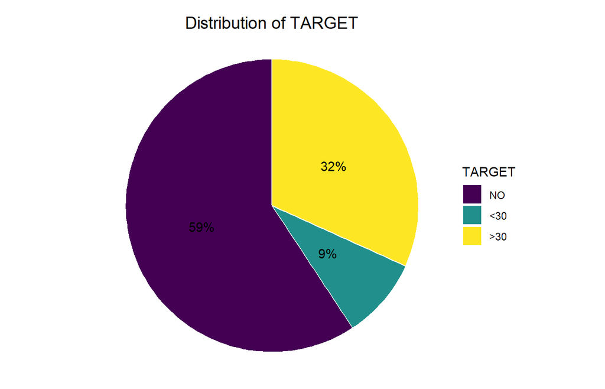

Fig. 1

```r
# Plot the distribution of the target variable TARGET
plot_pie_chart(diabetic_data_ter, "TARGET")
```

Finally, we create a dataset, `diabetic_data_bin`, for binary classification of hospital readmissions and plot the distribution of the binary `TARGET` variable using a pie chart.

```r
# FIlter out the TARGET >30
diabetic_data_bin <- diabetic_data_ter %>%
  filter(TARGET != ">30")

# Encode the TARGET as 1 or 0
diabetic_data_bin <- diabetic_data_bin %>%
  mutate(TARGET = case_when(TARGET == "<30" ~ "1",
                            TRUE ~ "0"),
         TARGET = as.factor(TARGET))

# Remove any levels from factor features that no longer occur
diabetic_data_bin <- droplevels(diabetic_data_bin)
```

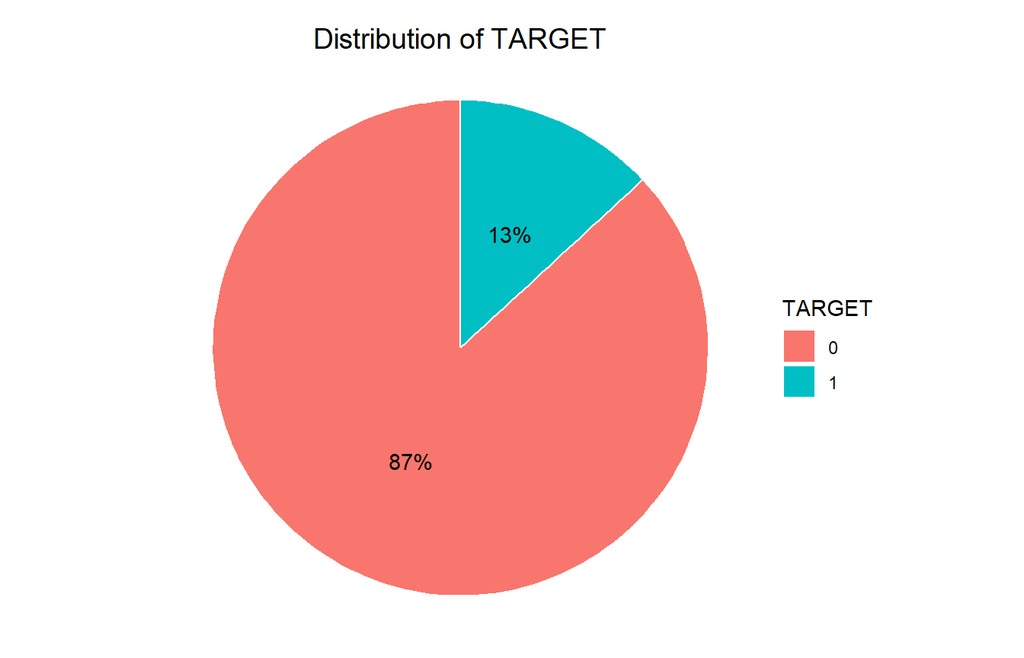

Fig. 2

```r
# Plot the distribution of the binary target variable TARGET
plot_pie_chart(diabetic_data_bin, "TARGET")
```

The imbalance in the target variable, with 87% of the data belonging to class 0 and 13% to class 1, poses several challenges for modeling:

- **Model bias**: Models may become biased toward predicting the majority class (0) due to its dominance in the data. This bias can lead to poor performance in identifying the minority class (1), especially when using metrics focused on the minority class, such as precision, recall, and F1-score.
- **Accuracy as a misleading metric**: In imbalanced datasets, high accuracy can be misleading. A model that always predicts the majority class (0) will achieve high accuracy (87%) but will fail to correctly predict the minority class (1), leading to a false sense of good performance.

To mitigate the impact of class imbalance during modeling in R, we can apply several techniques:

- **Resampling**: Use oversampling (e.g., SMOTE) or undersampling methods to balance the class distribution in the training data. This will be carried out in Part II.
- **Class weighting**: Assign higher weights to the minority class, which penalizes the model more for misclassifying the minority class.
- **Use specific evaluation metrics**: Assess performance using metrics like precision, recall, F1-score, or ROC-AUC, which provide a clearer picture of the model’s ability to handle imbalanced data.
- **Use ensemble methods**: Algorithms like Random Forest or XGBoost tend to be more robust to class imbalance. These models aggregate multiple trees, which may help capture patterns in the minority class more effectively.

Finally, we display the first ten rows of the preprocessed dataset and export it to a CSV file for later use.

```r
# Display the first ten rows of `diabetic_data_bin`
head(diabetic_data_bin, 10)
```

```
## # A tibble: 10 × 51
##    race            gender age    weight admission_type_id discharge_dispositio…¹
##    <fct>           <fct>  <ord>  <ord>  <fct>             <fct>
##  1 Caucasian       Female [50-6… ?      2                 1
##  2 Caucasian       Female [50-6… ?      3                 1
##  3 Caucasian       Female [80-9… ?      1                 3
##  4 Caucasian       Female [80-9… ?      1                 1
##  5 AfricanAmerican Female [30-4… ?      1                 1
##  6 Caucasian       Female [60-7… ?      3                 1
##  7 Caucasian       Female [70-8… ?      2                 3
##  8 Caucasian       Male   [60-7… ?      2                 1
##  9 Caucasian       Female [70-8… ?      3                 1
## 10 Caucasian       Female [80-9… ?      1                 3
## # ℹ abbreviated name: ¹discharge_disposition_id
## # ℹ 45 more variables: admission_source_id <fct>, time_in_hospital <int>,
## #   payer_code <fct>, medical_specialty <fct>, num_lab_procedures <int>,
## #   num_procedures <int>, num_medications <int>, number_outpatient <int>,
## #   number_emergency <int>, number_inpatient <int>, diag_1 <fct>, diag_2 <fct>,
## #   diag_3 <fct>, number_diagnoses <int>, max_glu_serum <ord>, A1Cresult <ord>,
## #   metformin <ord>, repaglinide <ord>, nateglinide <ord>, …
```

```r
# Export the entire dataset as a CSV file
diabetic_data_bin %>% write_csv("../02_tidy_data/diabetic_data_bin.csv")

# Remove objects that are no longer needed for the subsequent analysis
rm(diabetic_data, dat, CCS_categories_ICD9, CCS_mapping_ICD9, icd9_data, icd9)
```

# 4 Task R2: Exploratory Data Analysis and Visualization

In this task, code snippets from the SWoF template must be extracted and modified in certain places. The objective of these modifications is to ensure the code runs with minimal adjustments, using the dataset `diabetic_data_bin`, which was created at the end of Task R1, as input. At the beginning of each relevant subtask, the corresponding section of the SWoF template is indicated in bold.

Note: *For all visualizations created in this task, ensure clarity, consistency, and readability. Points will be deducted for failing to meet this requirement.*

## 4.1 a) 3 Overview

Apply the functions summary and glimpse to the dataset `diabetic_data_bin` and briefly discuss the results.

**Solution:**

As a first step let’s have an overview of the data sets using the *summary* and *glimpse* tools.

```r
summary(diabetic_data_bin)
```

```
##               race          gender           age              weight
##  ?              : 1483   Female:25152   [70-80):11623   ?        :46283
##  AfricanAmerican: 8757   Male  :22599   [60-70):10736   [75-100) :  589
##  Asian          :  381                  [50-60): 8615   [50-75)  :  428
##  Caucasian      :35203                  [80-90): 7242   [100-125):  304
##  Hispanic       : 1088                  [40-50): 4885   [125-150):   70
##  Other          :  839                  [30-40): 2003   [25-50)  :   43
##                                         (Other): 2647   (Other)  :   34
##  admission_type_id discharge_disposition_id admission_source_id
##  1:24036           1      :30258            7      :24540
##  2: 8731           3      : 6029            1      :15312
##  3:10056           6      : 5189            17     : 3090
##  5: 2047           18     : 1921            4      : 2021
##  6: 2641           2      : 1101            6      : 1479
##  7:   18           22     : 1073            2      :  673
##  8:  222           (Other): 2180            (Other):  636
##  time_in_hospital   payer_code                 medical_specialty
##  Min.   : 1.000   ?      :20378   ?                     :22642
##  1st Qu.: 2.000   MC     :13115   InternalMedicine      : 7341
##  Median : 3.000   HM     : 2821   Family/GeneralPractice: 3312
##  Mean   : 4.205   BC     : 2601   Emergency/Trauma      : 2875
##  3rd Qu.: 6.000   SP     : 2259   Cardiology            : 2811
##  Max.   :14.000   MD     : 1522   Surgery-General       : 1528
##                   (Other): 5055   (Other)               : 7242
##  num_lab_procedures num_procedures  num_medications number_outpatient
##  Min.   :  1.00     Min.   :0.000   Min.   : 1.00   Min.   : 0.000
##  1st Qu.: 30.00     1st Qu.:0.000   1st Qu.:10.00   1st Qu.: 0.000
##  Median : 44.00     Median :1.000   Median :14.00   Median : 0.000
##  Mean   : 42.36     Mean   :1.458   Mean   :15.56   Mean   : 0.233
##  3rd Qu.: 56.00     3rd Qu.:2.000   3rd Qu.:20.00   3rd Qu.: 0.000
##  Max.   :132.00     Max.   :6.000   Max.   :81.00   Max.   :36.000
##
##  number_emergency   number_inpatient      diag_1          diag_2
##  Min.   : 0.00000   Min.   : 0.0000   414    : 3641   250    : 3748
##  1st Qu.: 0.00000   1st Qu.: 0.0000   428    : 2219   276    : 3047
##  Median : 0.00000   Median : 0.0000   786    : 2063   428    : 2589
##  Mean   : 0.08157   Mean   : 0.1383   410    : 2006   401    : 2309
##  3rd Qu.: 0.00000   3rd Qu.: 0.0000   486    : 1488   427    : 2283
##  Max.   :37.00000   Max.   :12.0000   715    : 1418   599    : 1495
##                                       (Other):34916   (Other):32280
```

[output cut: 49 more lines]

```
##  Ch:21017   No :12040   0:41474   Circulatory:14395   Circulatory  :14079
##  No:26734   Yes:35711   1: 6277   Other      : 8104   Other        :12432
##                                   Respiratory: 6032   Diabetes     : 7141
##                                   Digestive  : 4229   Respiratory  : 4461
##                                   Diabetes   : 3895   Genitourinary: 3612
##                                   Injury     : 3374   Digestive    : 1830
##                                   (Other)    : 7722   (Other)      : 4196
##         group_diag_3
##  Circulatory  :13433
##  Other        :13108
##  Diabetes     : 9444
##  Respiratory  : 3017
##  Genitourinary: 2676
##  Digestive    : 1644
##  (Other)      : 4429
```

```r
glimpse(diabetic_data_bin)
```

```
## Rows: 47,751
## Columns: 51
## $ race                       <fct> Caucasian, Caucasian, Caucasian, Caucasian,…
## $ gender                     <fct> Female, Female, Female, Female, Female, Fem…
## $ age                        <ord> [50-60), [50-60), [80-90), [80-90), [30-40)…
## $ weight                     <ord> ?, ?, ?, ?, ?, ?, ?, ?, ?, ?, ?, ?, ?, ?, ?…
## $ admission_type_id          <fct> 2, 3, 1, 1, 1, 3, 2, 2, 3, 1, 1, 1, 3, 3, 1…
## $ discharge_disposition_id   <fct> 1, 1, 3, 1, 1, 1, 3, 1, 1, 3, 1, 1, 5, 1, 1…
## $ admission_source_id        <fct> 1, 1, 7, 7, 7, 1, 1, 1, 1, 7, 7, 7, 1, 1, 7…
## $ time_in_hospital           <int> 8, 2, 4, 3, 5, 9, 12, 8, 1, 7, 4, 1, 4, 6, …
## $ payer_code                 <fct> ?, ?, MC, ?, ?, ?, ?, ?, ?, ?, ?, ?, ?, ?, …
## $ medical_specialty          <fct> Cardiology, Surgery-Neuro, InternalMedicine…
## $ num_lab_procedures         <int> 77, 49, 68, 46, 49, 52, 47, 57, 31, 77, 47,…
## $ num_procedures             <int> 6, 1, 2, 0, 0, 1, 2, 6, 1, 0, 4, 5, 2, 2, 3…
## $ num_medications            <int> 33, 11, 23, 20, 5, 16, 18, 31, 9, 12, 16, 1…
```

[output cut: 38 more lines]

We find the following:

- The dataset contains a large number of features, with a total of 47,751 rows and 51 variables, including the *id* and *target* columns.
- As outlined in the data description in *paper.pdf*, most variables are nominal, with the exception of 8 integer variables. These nominal variables are represented as factors in the dataset.
- Key variables include:
  - **Demographics**: `race`, `gender`, `age`, `weight`, with some missing or unknown values (?), especially for `weight`.
  - **Hospitalization**: `admission_type_id`, `discharge_disposition_id`, `admission_source_id`, `time_in_hospital`, with most stays being short, as indicated by a median of 3 days.
  - **Medical Information**: `medical_specialty` with nearly half of the values being unknown (`?`), along with `number_diagnoses`, as well as `diag_x`, `diag_2`, `diag_3`, which contain detailed but sparse data.
  - **Lab and Medications**: Features such as `num_lab_procedures` and `num_medications`, which exhibit a skewed distribution with a long tail and high maximum values.
  - **Outcomes**: Variables such as `change`, `diabetesMed`, and the target variable `TARGET` (indicating whether the patient was readmitted or not).

## 4.2 b) 4 Individual feature visualisations

In the SWoF template, the features in the dataset are classified into different groups (Sections 4.1 to 4.9). Define a meaningful grouping of the features in the dataset `diabetic_data_bin` (excluding `diag_1`, `diag_2`, `diag_3`) into four to seven groups and justify your choice. For each group, create histograms and kernel density estimator plots for the respective features, ensuring they resemble those in Sections 4.1 to 4.9 of the template. Use the function `multiplot` and apply a logarithmic *y*-axis where appropriate. Discuss the key insights derived from the visualizations, particularly in terms of their relevance for predicting the target variable TARGET.

**Solution:**

We begin our exploration with distribution plots for the various features. To make this visualization more comprehensive, we will organize the features into specific groups and create layouts for each. For readability, we will divide each group into multiple parts:

- **Demographic features**: `race`, `gender`, `age`, `weight`;
- **Administrative and provider features**: `admission_type_id`, `discharge_disposition_id`, `admission_source_id`, `payer_code`, `medical_specialty`;
- **Patient utillisation history**: `time_in_hospital`, `num_lab_procedures`, `num_procedures`, `num_medications`, `number_outpatient`, `number_emergency`, `number_inpatient`, `number_diagnoses`, all defined in terms of integers;
- **Lab test results**: `max_glu_serum`, `A1Cresult`;
- **Medication results**:
  - **Overall**: `change`, `diabetesMed` (each with two possible values);
  - **Unary**: `acetohexamide`, `troglitazone`, `examide`, `citoglipton`, `glipizide-metformin`, `glimepiride-pioglitazone`, `metformin-rosiglitazone`, `metformin-pioglitazone` (each with only one possible value);
  - **Binary**: `chlorpropamide`, `tolbutamide`, `miglitol`, `tolazamide`, `glyburide-metformin` (each with two possible values);
  - **The rest**: `metformin`, `repaglinide`, `nateglinide`, `glimepiride`, `glipizide`, `glyburide`, `pioglitazone`, `rosiglitazone`, `acarbose`, `insulin` (each with at least three possible values);
- **Diagnosis**: `group_diag_1`, `group_diag_2`, `group_diag_3`;
- **Target variable**: `TARGET`.

These plots will be one of the pillars of our analysis. They might not be particularly exciting in themselves, but whenever we find an interesting effect in one of the variables we can come back here and examine their distribution. It’s always an advantage to start with a clear view of the parameter space.

```r
# Function to plot a bar chart given a dataset 'dat'
# and name of the variable 'cat_var'
plot_bar_chart <- function(dat, cat_var) {
  dat %>%
    # Reorder the feature by count
    ggplot(aes(x = !!sym(cat_var), fill = !!sym(cat_var))) +
    geom_bar() +
    theme(legend.position = "none",
          axis.text.x = element_text(angle = 45, size = 9, hjust = 1)) +
    labs(x = cat_var)
}

# Function to adjust axes and optionally apply a log scale to the y-axis
adjust_axis <- function(ggplot, log_y = TRUE, size_axis_title = 12, size_axis_label = 10) {
  ggplot <- ggplot +
    theme(
      axis.title = element_text(size = size_axis_title),
      axis.text.x = element_text(size = size_axis_label))

  if (log_y) {
    ggplot <- ggplot + scale_y_log10()  # Apply logarithmic scale to the y-axis
  }

  return(ggplot)
}
```

### 4.2.1 Demographic features

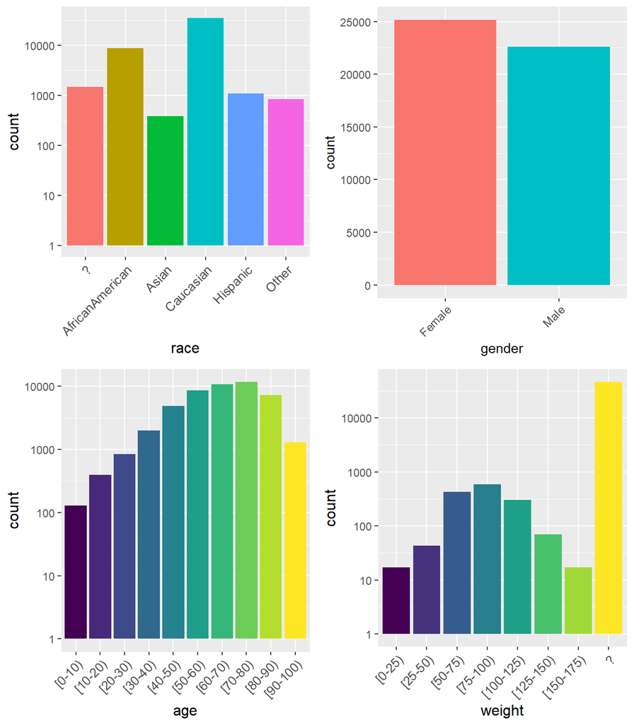

Fig. 3

```r
p1 <- adjust_axis(plot_bar_chart(diabetic_data_bin, "race"))
p2 <- plot_bar_chart(diabetic_data_bin, "gender")
p3 <- adjust_axis(plot_bar_chart(diabetic_data_bin, "age"))
p4 <- adjust_axis(plot_bar_chart(diabetic_data_bin, "weight"))

layout <- matrix(1:4, 2, 2, byrow = TRUE)
multiplot(p1, p2, p3, p4, layout = layout)
```

### 4.2.2 Administrative and provider features

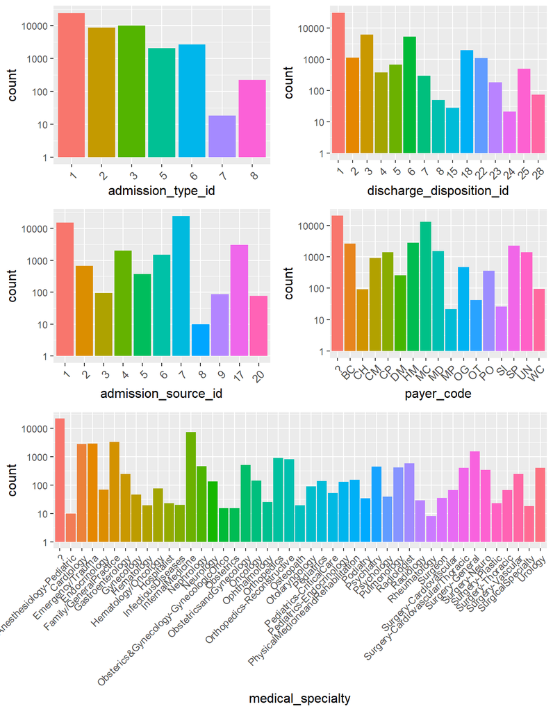

Fig. 4

```r
p1 <- adjust_axis(plot_bar_chart(diabetic_data_bin, "admission_type_id"))
p2 <- adjust_axis(plot_bar_chart(diabetic_data_bin, "discharge_disposition_id"))
p3 <- adjust_axis(plot_bar_chart(diabetic_data_bin, "admission_source_id"))
p4 <- adjust_axis(plot_bar_chart(diabetic_data_bin, "payer_code"))
p5 <- plot_bar_chart(diabetic_data_bin, "medical_specialty") +
  scale_y_log10() +
  theme(axis.title = element_text(size = 12))

layout <- matrix(c(rep(1:2, 2), rep(3:4, 2), rep(5, 6)), 7, 2, byrow = TRUE)
multiplot(p1, p2, p3, p4, p5, layout = layout)
```

Key insights from the visualization of these features are:

### 4.2.3 Patient utillisation history part 1

```r
# Plot a pie chart given a dataset 'dat' and name of the variable 'cont_var'
plot_histogram <- function(dat, cont_var, binwidth) {
  dat %>%
    ggplot(aes(x = !!sym(cont_var))) +
    geom_histogram(fill = "blue", alpha = 0.5, binwidth = binwidth) +
    scale_y_log10() +  # With logarithmic y-axes
    theme(legend.position = "none")
}

# Create KDE plot given a dataset 'dat' and name of the variable 'cont_var'
plot_KDE <- function(dat, cont_var) {
  dat %>%
    ggplot(aes(x = !!sym(cont_var))) +
    geom_density(fill = "blue", alpha = 0.5) +
    theme(legend.position = "none")
}
```

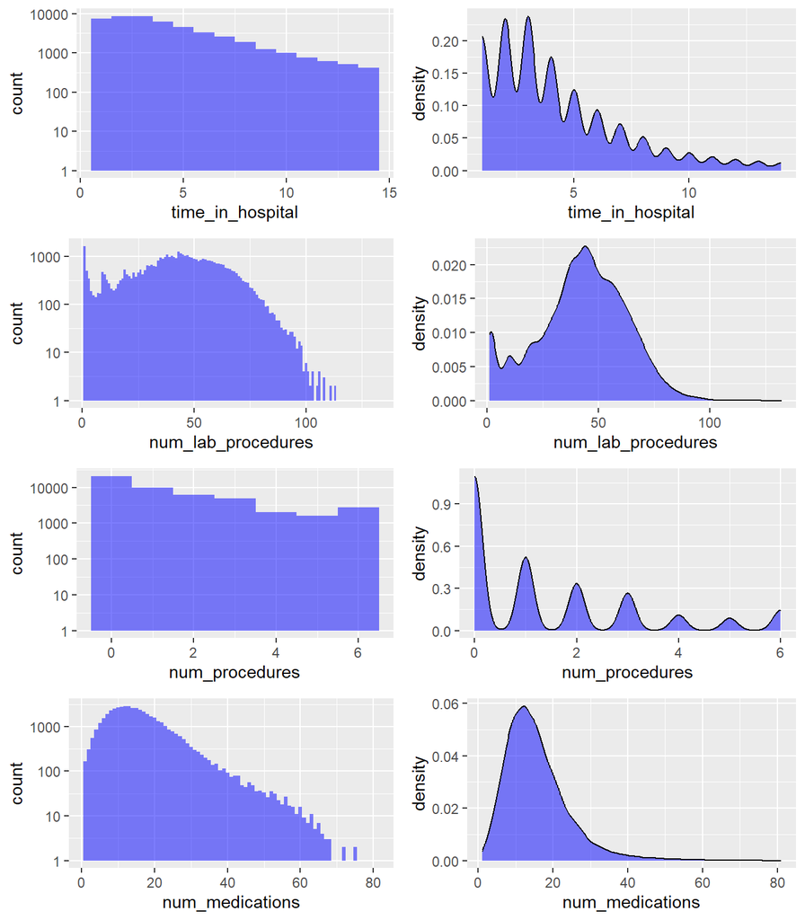

Fig. 5

```r
p1 <- plot_histogram(diabetic_data_bin, "time_in_hospital", binwidth = 1)
p2 <- plot_KDE(diabetic_data_bin, "time_in_hospital")
p3 <- plot_histogram(diabetic_data_bin, "num_lab_procedures", binwidth = 1)
p4 <- plot_KDE(diabetic_data_bin, "num_lab_procedures")
p5 <- plot_histogram(diabetic_data_bin, "num_procedures", binwidth = 1)
p6 <- plot_KDE(diabetic_data_bin, "num_procedures")
p7 <- plot_histogram(diabetic_data_bin, "num_medications", binwidth = 1)
p8 <- plot_KDE(diabetic_data_bin, "num_medications")

layout <- matrix(1:8, 4, 2, byrow=TRUE)
multiplot(p1, p2, p3, p4, p5, p6, p7, p8, layout=layout)
```

### 4.2.4 Patient utillisation history part 2

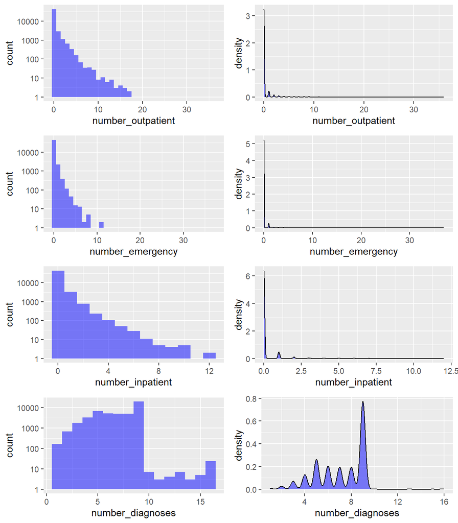

Fig. 6

```r
p9 <- plot_histogram(diabetic_data_bin, "number_outpatient", binwidth = 1)
p10 <- plot_KDE(diabetic_data_bin, "number_outpatient")
p11 <- plot_histogram(diabetic_data_bin, "number_emergency", binwidth = 1)
p12 <- plot_KDE(diabetic_data_bin, "number_emergency")
p13 <- plot_histogram(diabetic_data_bin, "number_inpatient", binwidth = 1)
p14 <- plot_KDE(diabetic_data_bin, "number_inpatient")
p15 <- plot_histogram(diabetic_data_bin, "number_diagnoses", binwidth = 1)
p16 <- plot_KDE(diabetic_data_bin, "number_diagnoses")

layout <- matrix(1:8, 4, 2, byrow = TRUE)
multiplot(p9, p10, p11, p12, p13, p14, p15, p16, layout=layout)
```

Key insights:

- `number_outpatient` and `number_emergency` are both highly right-skewed, with the majority of patients having 0 or 1 such visits. Only a very small number of patients have more than 30 outpatient or emergency encounters. This strong imbalance suggests that these features may carry limited predictive power for readmission, especially without transformation or binning.
- `number_inpatient`, while also right-skewed, represents prior hospitalizations, which are well-known to be among the strongest predictors of future hospitalizations. This makes it a particularly valuable feature in modeling readmission risk.
- `number_diagnoses` is more evenly distributed, with most values ranging between 1 and 9. There is a noticeable drop-off beyond 9, likely due to system or reporting limits. Since a higher number of diagnoses typically reflects greater comorbidity, this feature is likely to be an important predictor of readmission.

### 4.2.5 Lab test results

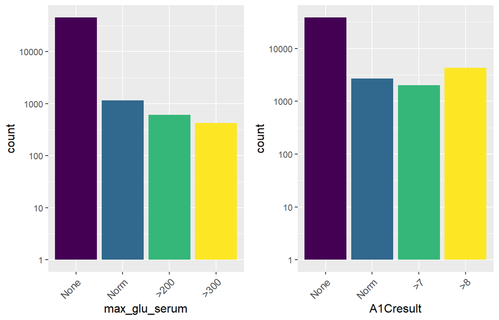

Fig. 7

```r
p1 <- adjust_axis(plot_bar_chart(diabetic_data_bin, "max_glu_serum"))
p2 <- adjust_axis(plot_bar_chart(diabetic_data_bin, "A1Cresult"))

layout <- matrix(1:2, 1, 2, byrow = TRUE)
multiplot(p1, p2, layout = layout)
```

Key insights:

- The majority of records show “None” for both `max_glu_serum` and `A1Cresult`, indicating that these tests were not performed or results were not recorded for most patients.
- However, a non-negligible portion of the data includes elevated glucose levels (e.g., `>200`, `>300`) and high A1C values (e.g., `>7`, `>8`).
- Elevated glucose and A1C values are strong clinical indicators that may trigger immediate adjustments in medication or care plans, which could lead to closer monitoring and potentially lower readmission rates if managed appropriately.

### 4.2.6 Medication results - overall

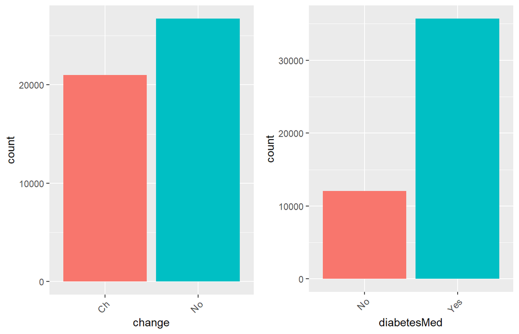

Fig. 8

```r
p1 <- plot_bar_chart(diabetic_data_bin, "change")
p2 <- plot_bar_chart(diabetic_data_bin, "diabetesMed")

layout <- matrix(1:2, 1, 2, byrow = TRUE)
multiplot(p1, p2, layout = layout)
```

Key insights:

- A significant number of patients have “No” recorded for the `change` variable, indicating no adjustment to their medication regimen during the encounter.
- The majority of patients are on some form of diabetes medication (`diabetesMed` == “Yes”), suggesting that pharmacological treatment is common in this population.

These two features, `change` and `diabetesMed`, can reflect different aspects of disease management. A medication change may signal a worsening or improvement in the patient’s condition, prompting clinicians to adjust treatment. In contrast, patients on medication but with no changes could represent either stable management or possibly neglected care if adjustments were needed but not made. Thus, while these features are potentially informative, they require clinical context to interpret their implications for readmission risk accurately.

### 4.2.7 Medication results - unary

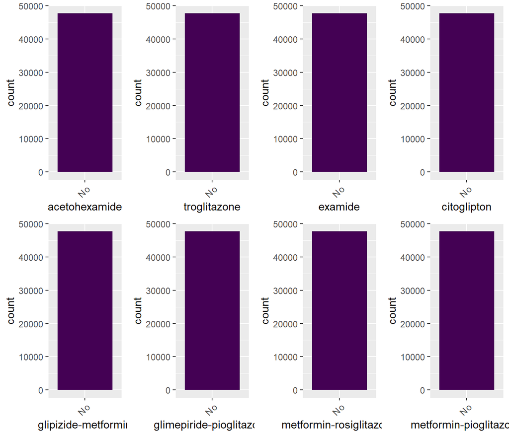

Fig. 9

```r
p1 <- plot_bar_chart(diabetic_data_bin, "acetohexamide")
p2 <- plot_bar_chart(diabetic_data_bin, "troglitazone")
p3 <- plot_bar_chart(diabetic_data_bin, "examide")
p4 <- plot_bar_chart(diabetic_data_bin, "citoglipton")
p5 <- plot_bar_chart(diabetic_data_bin, "glipizide-metformin")
p6 <- plot_bar_chart(diabetic_data_bin, "glimepiride-pioglitazone")
p7 <- plot_bar_chart(diabetic_data_bin, "metformin-rosiglitazone")
p8 <- plot_bar_chart(diabetic_data_bin, "metformin-pioglitazone")

layout <- matrix(1:8, 2, 4, byrow = TRUE)
multiplot(p1, p2, p3, p4, p5, p6, p7, p8, layout = layout)
```

These diabetes medications features contain only a single unique value across all records. These features are deterministic and carry no variance, making them irrelevant for predictive modeling.

### 4.2.8 Medication results - binary

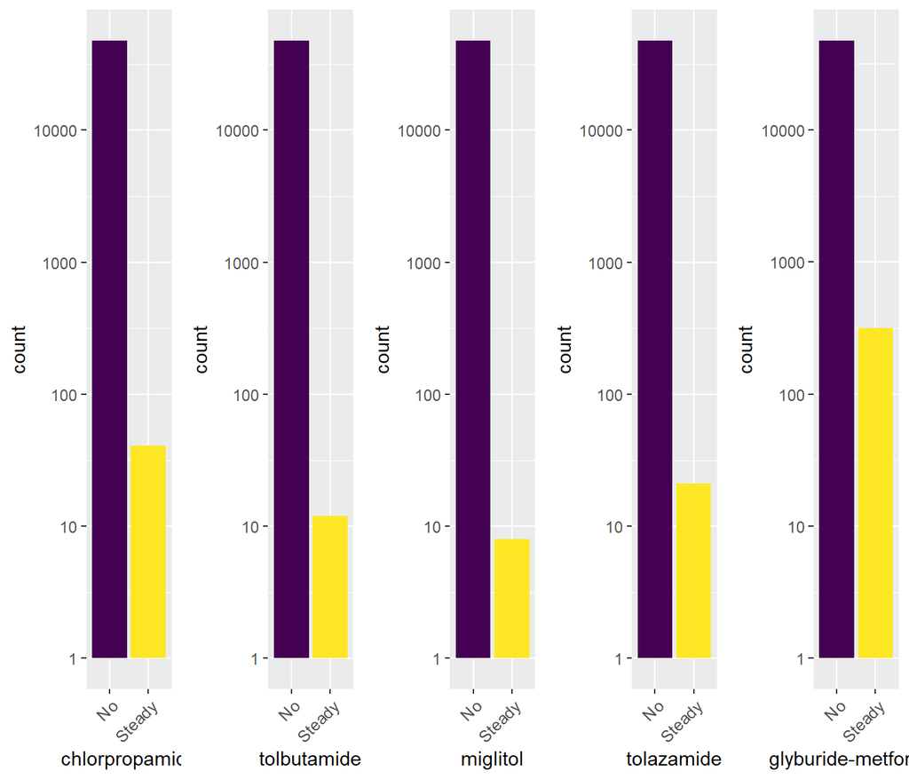

Fig. 10

```r
p1 <- plot_bar_chart(diabetic_data_bin, "chlorpropamide") + scale_y_log10()
p2 <- plot_bar_chart(diabetic_data_bin, "tolbutamide") + scale_y_log10()
p3 <- plot_bar_chart(diabetic_data_bin, "miglitol") + scale_y_log10()
p4 <- plot_bar_chart(diabetic_data_bin, "tolazamide") + scale_y_log10()
p5 <- plot_bar_chart(diabetic_data_bin, "glyburide-metformin") + scale_y_log10()

layout <- matrix(1:5, 1, 5, byrow = TRUE)
multiplot(p1, p2, p3, p4, p5, layout = layout)
```

The diabetic medications `chlorpropamide`, `tolbutamide`, `miglitol`, `tolazamide`, and `glyburide-metformin` show highly imbalanced distributions, with the vast majority of entries indicating `No` usage. These medications are rarely prescribed in the dataset, which leads to very low variability and minimal exposure.

As a result, they are unlikely to serve as reliable or meaningful predictors in the readmission classification task. Their inclusion could even introduce noise or increase the risk of overfitting in certain models, especially those sensitive to rare categories.

### 4.2.9 Medication results - otherwise

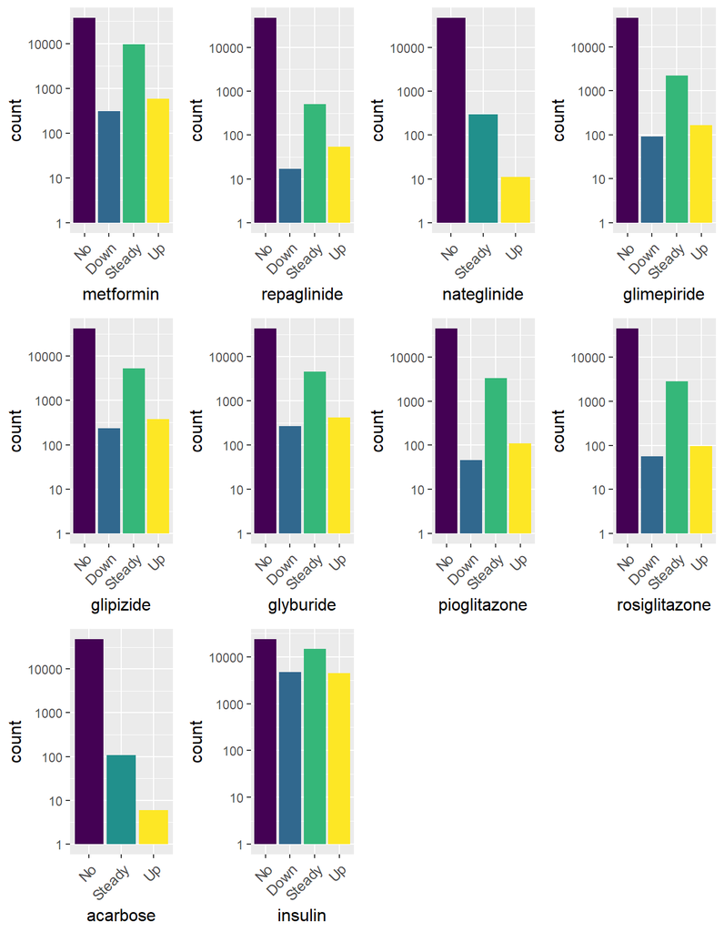

Fig. 11

```r
p1 <- adjust_axis(plot_bar_chart(diabetic_data_bin, "metformin"))
p2 <- adjust_axis(plot_bar_chart(diabetic_data_bin, "repaglinide"))
p3 <- adjust_axis(plot_bar_chart(diabetic_data_bin, "nateglinide"))
p4 <- adjust_axis(plot_bar_chart(diabetic_data_bin, "glimepiride"))
p5 <- adjust_axis(plot_bar_chart(diabetic_data_bin, "glipizide"))
p6 <- adjust_axis(plot_bar_chart(diabetic_data_bin, "glyburide"))
p7 <- adjust_axis(plot_bar_chart(diabetic_data_bin, "pioglitazone"))
p8 <- adjust_axis(plot_bar_chart(diabetic_data_bin, "rosiglitazone"))
p9 <- adjust_axis(plot_bar_chart(diabetic_data_bin, "acarbose"))
p10 <- adjust_axis(plot_bar_chart(diabetic_data_bin, "insulin"))

layout <- matrix(1:12, 3, 4, byrow = TRUE)
multiplot(p1, p2, p3, p4, p5, p6, p7, p8, p9, p10, layout = layout)
```

- For the rest of the diabetic medications, `No` category is predominant. However, for critical drugs such as `insulin` and `metformin`, the `Up` (dosage increase) and `Down` (dosage decrease) categories are not negligible, indicating meaningful treatment adjustments in response to patients’ conditions.
- The absence of a prescribed medication (`No`) could reflect either a well-controlled disease not requiring that specific drug or possibly a gap in care, depending on the clinical context and comorbidity profile.
- `Steady` medication regimens may suggest better disease management, potentially associated with a lower risk of readmission.
- In contrast, patients experiencing dosage changes, whether increases (`Up`) or decreases (`Down`), may be in unstable health or undergoing active clinical reassessment, which could correlate with a higher likelihood of readmission.

### 4.2.10 Diagosis features

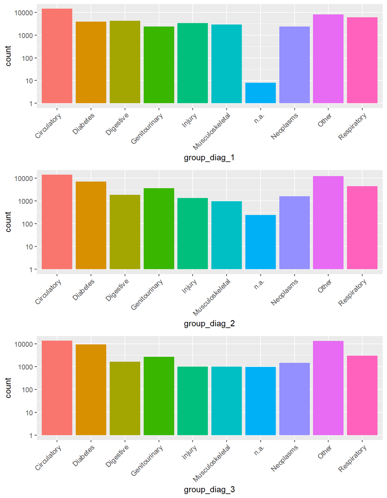

Fig. 12

```r
p1 <- plot_bar_chart(diabetic_data_bin, "group_diag_1") +
  scale_y_log10()

p2 <- plot_bar_chart(diabetic_data_bin, "group_diag_2") +
  scale_y_log10()

p3 <- plot_bar_chart(diabetic_data_bin, "group_diag_3") +
  scale_y_log10()

layout <- matrix(c(1, 2, 3), 3, 1, byrow = TRUE)
multiplot(p1, p2, p3, layout = layout)
```

The analysis of grouped diagnosis features within the dataset yields the following key insights:

- Circulatory system issues are the most common primary diagnoses, while diabetes-related, digestive, and respiratory conditions also appear frequently.
- The presence of n.a. (missing) diagnosis entries, especially in `diag_3`, is relatively low but not negligible. While not ideal, this level of missingness is unlikely to severely bias the analysis but may still require careful handling (e.g., a separate category).
- Diagnosis groups such as Circulatory and Diabetes are likely to be strong predictors of readmission, given their close clinical ties to poor outcomes and complications in diabetic populations.

### 4.2.11 Target variable

Finally, this is what it is all about: whether a patient has been readmitted (“1”) or not (“0”):

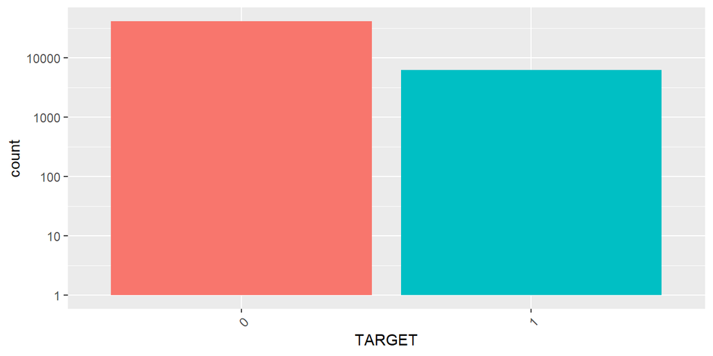

Fig. 13

```r
plot_bar_chart(diabetic_data_bin, "TARGET") + scale_y_log10()
```

- The target variable exhibits a **mild class imbalance**, with non-readmitted cases (TARGET = 0) being more frequent than readmitted cases (TARGET = 1).
- Despite this imbalance, the minority class still has substantial representation, which allows most standard classifiers to learn meaningful patterns without extreme correction.

## 4.3 c) 5 Claim rates for individual features

Calculate and visualize the relative frequencies of the target variable TARGET (i.e., the readmission rates) for each categorical feature, similar to Sections 5.1 to 5.4 of the template. For numerical features, proceed as described in Sections 5.5 and 5.6. Use the functions `multiplot` and `get_binCI`, and group the visualizations according to the grouping defined in subtask R2b). Discuss the key insights from the visualizations, particularly in terms of their relevance for predicting the target variable readmission prediction.

**Solution:**

In order to determine the importance of the individual parameters we will study the distribution of their *readmission rates*, i.e. how large a fraction per categorical variable ended up being readmitted within 30 days or how the distributions of readmission compared with those of no readmission. This analysis will follow a similar structure as above.

Here we estimate error bars from Binomial 95% confidence limits based on the count statistics of the *readmission vs no readmission* cases. These will help us to decide whether potential differences are significant or not. The corresponding helper function `get_binCI` is defined in Section 2.2 above.

```r
# Function to plot admission rate by categorical feature
plot_admission_by_category <- function(dat, cat_var) {
  dat %>%
    group_by(!!sym(cat_var), TARGET) %>%
    count() %>%
    spread(TARGET, n, fill = 0) %>%
    mutate(readmission_rate = `1`/(`1`+`0`)*100,
           lwr = get_binCI(`1`, (`1`+`0`))[[1]]*100,
           upr = get_binCI(`1`, (`1`+`0`))[[2]]*100
           ) %>%
    ggplot(aes(x = !!sym(cat_var), y = readmission_rate, fill = !!sym(cat_var))) +
  geom_col() +
  geom_errorbar(aes(ymin = lwr, ymax = upr), width = 0.5, size = 0.7, color = "gray30") +
  theme(legend.position = "none",
        axis.text.x = element_text(angle = 45, size = 9, hjust = 1)) +
  labs(x = cat_var, y = "Readmission [%]")
}
```

### 4.3.1 Demographic features

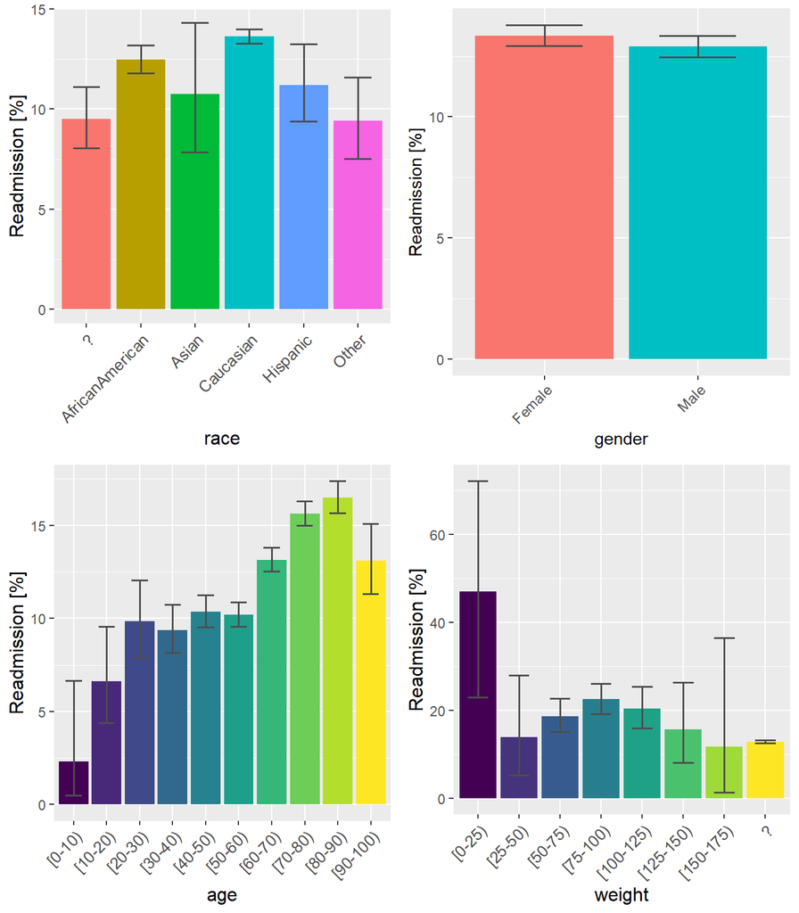

Fig. 14

```r
p1 <- adjust_axis(plot_admission_by_category(diabetic_data_bin, "race"), log_y = FALSE)
p2 <- plot_admission_by_category(diabetic_data_bin, "gender")
p3 <- adjust_axis(plot_admission_by_category(diabetic_data_bin, "age"), log_y = FALSE)
p4 <- adjust_axis(plot_admission_by_category(diabetic_data_bin, "weight"), log_y = FALSE)

layout <- matrix(1:4, 2, 2, byrow = TRUE)
multiplot(p1, p2, p3, p4, layout = layout)
```

Key insights:

- `race`: The dataset shows slight disparities in readmission rates by race, generally ranging from 10% to 13%. However, these differences are not substantial, and hence race does not appear to be a strong standalone predictor of readmission in this cohort.
- `gender`: Differences in readmission rates between male and female patients are minimal, indicating gender is not a strong standalone predictor either.
- `age`: A clear positive association is observed — older age groups tend to have higher readmission rates.
- `weight`: Extreme weight categories (e.g., underweight: [0–25) or severely overweight) may be linked to higher readmission risks. However, wide confidence intervals suggest limited statistical certainty, likely due to sparse data in those ranges.

### 4.3.2 Administrative and provider features

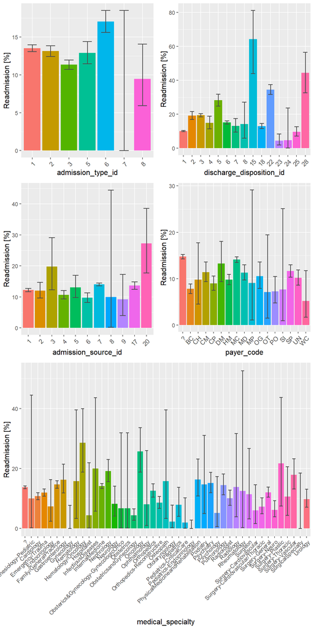

Fig. 15

```r
p1 <- adjust_axis(plot_admission_by_category(diabetic_data_bin, "admission_type_id"), log_y = FALSE)
p2 <- adjust_axis(plot_admission_by_category(diabetic_data_bin, "discharge_disposition_id"), log_y = FALSE)
p3 <- adjust_axis(plot_admission_by_category(diabetic_data_bin, "admission_source_id"), log_y = FALSE)
p4 <- adjust_axis(plot_admission_by_category(diabetic_data_bin, "payer_code"), log_y = FALSE)
p5 <- plot_admission_by_category(diabetic_data_bin, "medical_specialty") +
  theme(axis.title = element_text(size = 12))

layout <- matrix(c(rep(1:2, 2), rep(3:4, 2), rep(5, 6)), 7, 2, byrow = TRUE)
multiplot(p1, p2, p3, p4, p5, layout = layout)
```

### 4.3.3 Patient utillisation history part 1

For the numbering features we will now use a scatter plot with (95% confidence) error bars to emphasise the natural ordering of the values. Furthermore, for the sake of readability, we removed feature values occurs in the dataset fewer than ten times. Otherwise this would lead to a large statistical error bar that would dominate the plot and make it harder to read.

For features with a larger range of values, i.e. `num_lab_procedures` and `num_medications`, we’re switching to overlapping density plots.

```r
# Create a scatter plot for integer features
plot_admission_by_integer <- function(dat, int_var) {

  dat %>%
    group_by(!!sym(int_var), TARGET) %>%
    count() %>%
    spread(TARGET, n, fill = 0) %>%
    # Filter values with counts of at least 10
    filter((`1`+`0`) >= 10) %>%
    mutate(readmission_rate = `1`/(`1`+`0`)*100,
           lwr = get_binCI(`1`,(`1`+`0`))[[1]]*100,
           upr = get_binCI(`1`,(`1`+`0`))[[2]]*100
           ) %>%
    ggplot(aes(!!sym(int_var), readmission_rate)) +
    geom_point(color = "blue") +
    geom_errorbar(aes(ymin = lwr, ymax = upr), width = 0.5, size = 0.7, color = "blue") +
    theme(legend.position = "none") +
    labs(x = int_var, y = "Readmission [%]")
}

# Create a density plot for numeric features
plot_admission_density <- function(dat, cont_var) {
  dat %>%
    ggplot(aes(!!sym(cont_var), fill = TARGET)) +
    geom_density(alpha = 0.5)
}
```

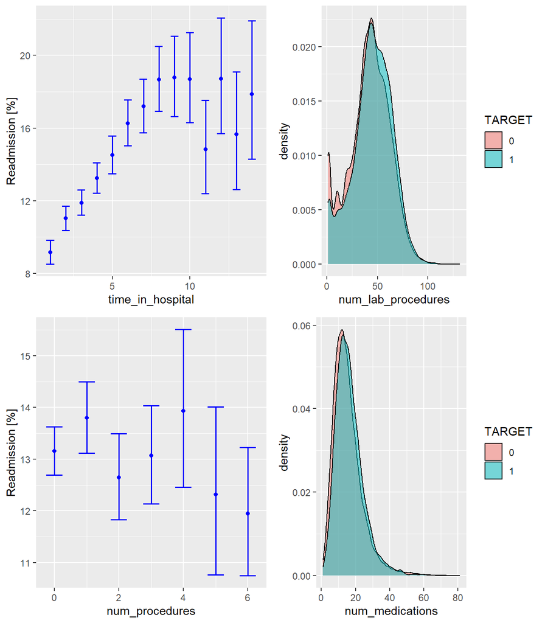

Fig. 16

```r
p1 <- plot_admission_by_integer(diabetic_data_bin, "time_in_hospital")
p2 <- plot_admission_density(diabetic_data_bin, "num_lab_procedures")
p3 <- plot_admission_by_integer(diabetic_data_bin, "num_procedures")
p4 <- plot_admission_density(diabetic_data_bin, "num_medications")

layout <- matrix(1:4, 2, 2, byrow = TRUE)
multiplot(p1, p2, p3, p4, layout = layout)
```

Key insights:

- `time_in_hospital`: Readmission rates increase steadily with the length of hospital stay, suggesting that more severe or complex cases are more prone to readmission, making it a potential predictor.
- `num_lab_procedures`: Patients with higher numbers of lab tests tend to be more concentrated among the readmitted group, showing moderate predictive value.
- `num_procedures`: Displays no clear trend in readmission rates. Additionally, higher variability among patients with ≥3 procedures suggests low reliability as a predictor.
- `num_medications`: Shows noticeable deviations in readmission rates, particularly in the mid-range (10–40 medications). This non-linear relationship hints at potential predictive power.

### 4.3.4 Patient utillisation history part 2

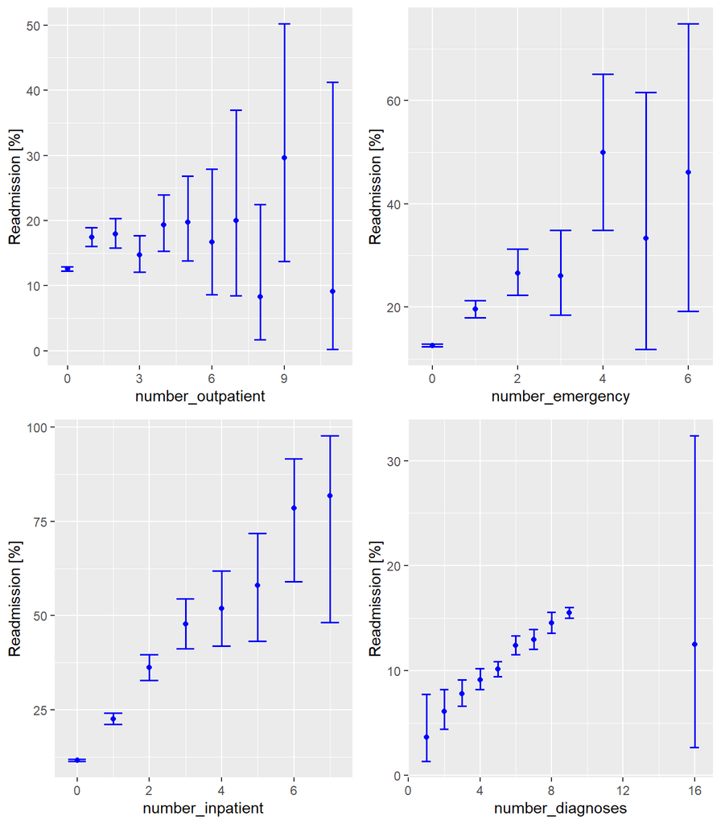

Fig. 17

```r
p5 <- plot_admission_by_integer(diabetic_data_bin, "number_outpatient")
p6 <- plot_admission_by_integer(diabetic_data_bin, "number_emergency")
p7 <- plot_admission_by_integer(diabetic_data_bin, "number_inpatient")
p8 <- plot_admission_by_integer(diabetic_data_bin, "number_diagnoses")

layout <- matrix(1:4, 2, 2, byrow = TRUE)
multiplot(p5, p6, p7, p8, layout = layout)
```

Key insights:

- All these variables exhibit stronger signals in *readmission rates* compared to simple frequency distributions, underscoring their predictive value.
- `number_emergency` and `number_inpatient` exhibits a clear positive correlation with readmission rate, whereas `number_outpatient` displays a slight upward trend but with greater variability at higher values.
- `number_diagnoses` exhibits a monotonically increasing trend in readmission rate, making this feature a strong and consistent predictor.

### 4.3.5 Lab test results

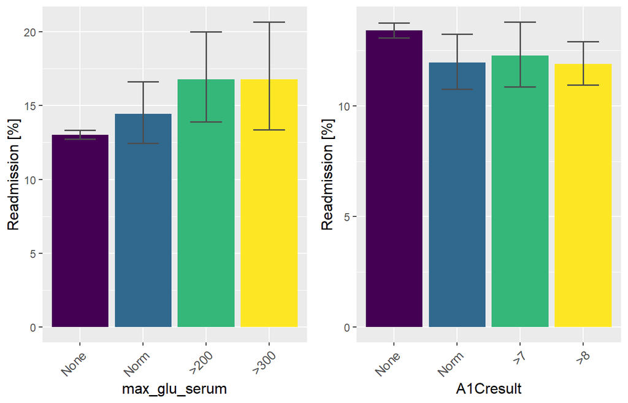

Fig. 18

```r
p1 <- adjust_axis(plot_admission_by_category(diabetic_data_bin, "max_glu_serum"), log_y = FALSE)
p2 <- adjust_axis(plot_admission_by_category(diabetic_data_bin, "A1Cresult"), log_y = FALSE)

layout <- matrix(1:2, 1, 2, byrow = TRUE)
multiplot(p1, p2, layout = layout)
```

Key insights:

- `max_glu_serum`: Elevated glucose levels (`>200` or `>300`) are clearly associated with higher readmission rates
- `A1Cresult`: While the presence of an HbA1c test (as opposed to “None”) is generally linked to lower readmission rates, the actual HbA1c levels (even `>7` or `>8`) do not show a strong, consistent signal in predicting readmission.

### 4.3.6 Medication results - overall

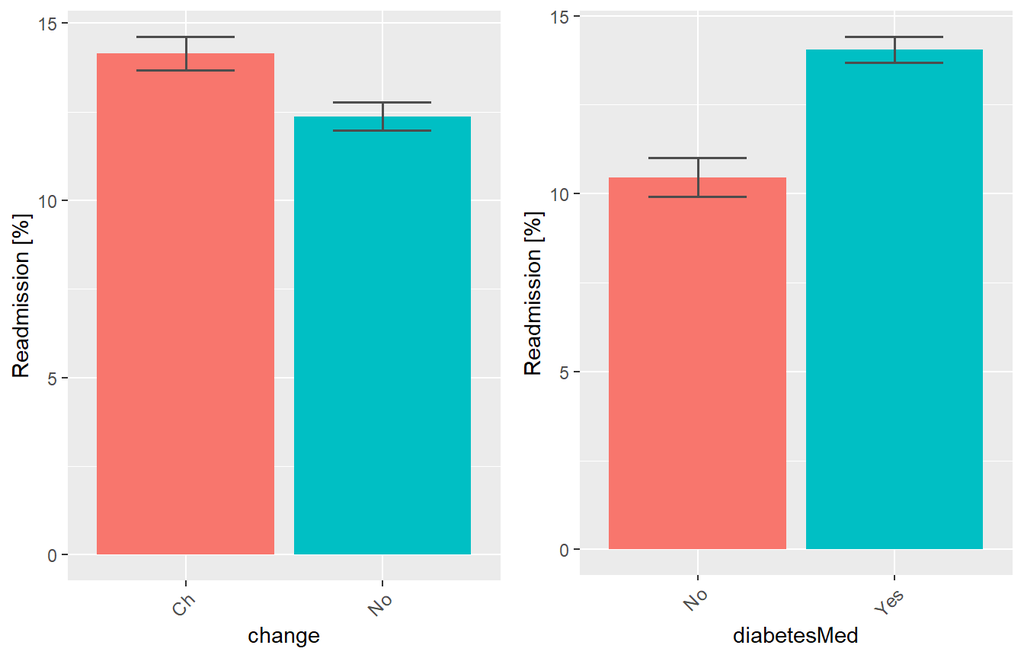

Fig. 19

```r
p1 <- plot_admission_by_category(diabetic_data_bin, "change")
p2 <- plot_admission_by_category(diabetic_data_bin, "diabetesMed")

layout <- matrix(1:2, 1, 2, byrow = TRUE)
multiplot(p1, p2, layout = layout)
```

Key insights:

- Medication Change (`change`): Patients whose medications were changed (~14.5% readmission) experienced higher readmission rates compared to those with no change (~12.5%). However, the difference is relatively modest, suggesting that while medication change may indicate underlying health shifts, its predictive power on its own is limited.
- Use of Diabetes Medication (`diabetesMed`): Patients on diabetes medication had a higher readmission rate (~14%) than those not on such medication (~10.5%). This suggests that active diabetes management, possibly due to more severe conditions, is linked to increased risk of readmission.

### 4.3.7 Medication results - unary

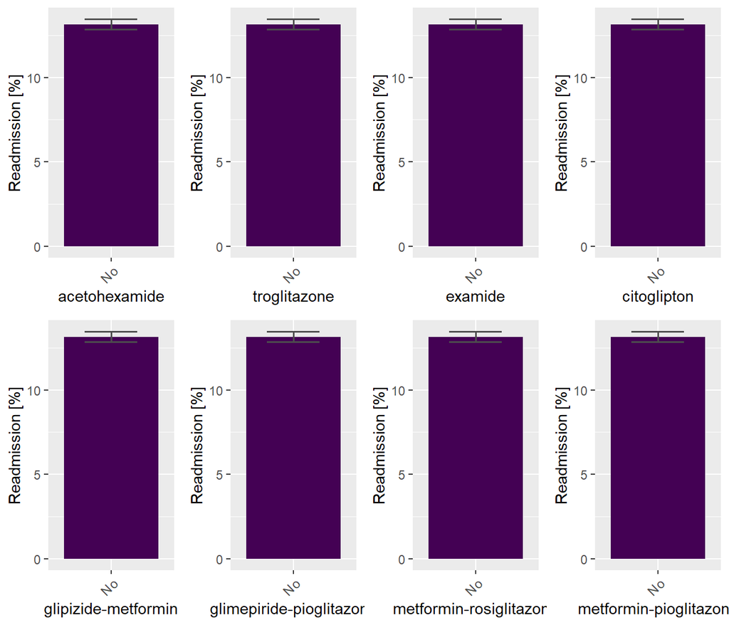

Fig. 20

```r
p1 <- plot_admission_by_category(diabetic_data_bin, "acetohexamide")
p2 <- plot_admission_by_category(diabetic_data_bin, "troglitazone")
p3 <- plot_admission_by_category(diabetic_data_bin, "examide")
p4 <- plot_admission_by_category(diabetic_data_bin, "citoglipton")
p5 <- plot_admission_by_category(diabetic_data_bin, "glipizide-metformin")
p6 <- plot_admission_by_category(diabetic_data_bin, "glimepiride-pioglitazone")
p7 <- plot_admission_by_category(diabetic_data_bin, "metformin-rosiglitazone")
p8 <- plot_admission_by_category(diabetic_data_bin, "metformin-pioglitazone")

layout <- matrix(1:8, 2, 4, byrow = TRUE)
multiplot(p1, p2, p3, p4, p5, p6, p7, p8, layout = layout)
```

Again, these features do not contribute any discriminative information and hence can be safely ignored without loss of predictive power.

### 4.3.8 Medication results - binary

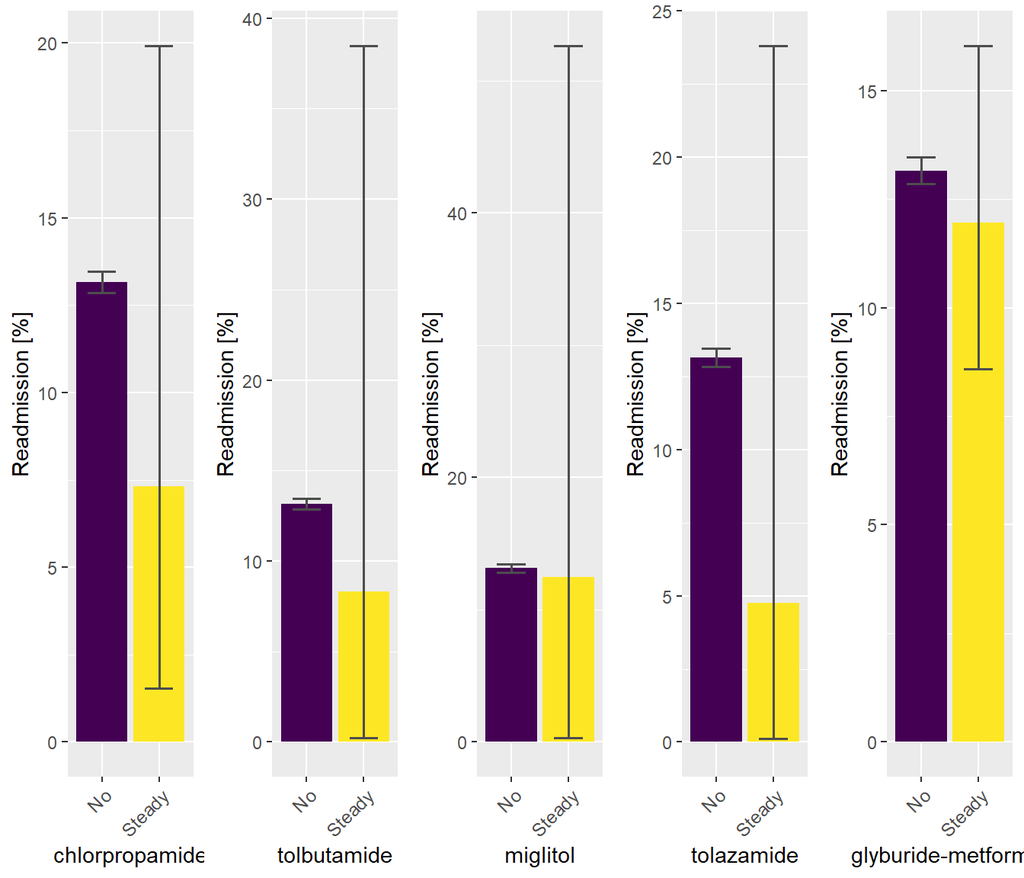

Fig. 21

```r
p1 <- plot_admission_by_category(diabetic_data_bin, "chlorpropamide")
p2 <- plot_admission_by_category(diabetic_data_bin, "tolbutamide")
p3 <- plot_admission_by_category(diabetic_data_bin, "miglitol")
p4 <- plot_admission_by_category(diabetic_data_bin, "tolazamide")
p5 <- plot_admission_by_category(diabetic_data_bin, "glyburide-metformin")

layout <- matrix(1:5, 1, 5, byrow = TRUE)
multiplot(p1, p2, p3, p4, p5, layout = layout)
```

Key insights:

- Patients on a steady regimen generally exhibit lower readmission rates than those not on the drug.
- However, large error bars suggest high statistical uncertainty. Combined with their limited exposure, this implies that these medications may not serve as strong individual predictors of readmission.

### 4.3.9 Medication results - otherwise

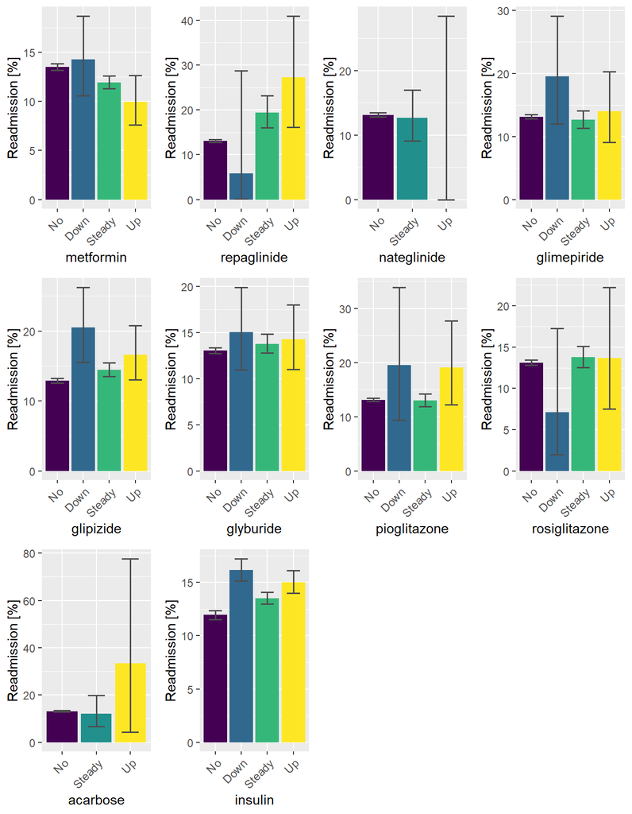

Fig. 22

```r
p1 <- plot_admission_by_category(diabetic_data_bin, "metformin")
p2 <- plot_admission_by_category(diabetic_data_bin, "repaglinide")
p3 <- plot_admission_by_category(diabetic_data_bin, "nateglinide")
p4 <- plot_admission_by_category(diabetic_data_bin, "glimepiride")
p5 <- plot_admission_by_category(diabetic_data_bin, "glipizide")
p6 <- plot_admission_by_category(diabetic_data_bin, "glyburide")
p7 <- plot_admission_by_category(diabetic_data_bin, "pioglitazone")
p8 <- plot_admission_by_category(diabetic_data_bin, "rosiglitazone")
p9 <- plot_admission_by_category(diabetic_data_bin, "acarbose")
p10 <- plot_admission_by_category(diabetic_data_bin, "insulin")

layout <- matrix(1:12, 3, 4, byrow = TRUE)
multiplot(p1, p2, p3, p4, p5, p6, p7, p8, p9, p10, layout = layout)
```

### 4.3.10 Diagosis features

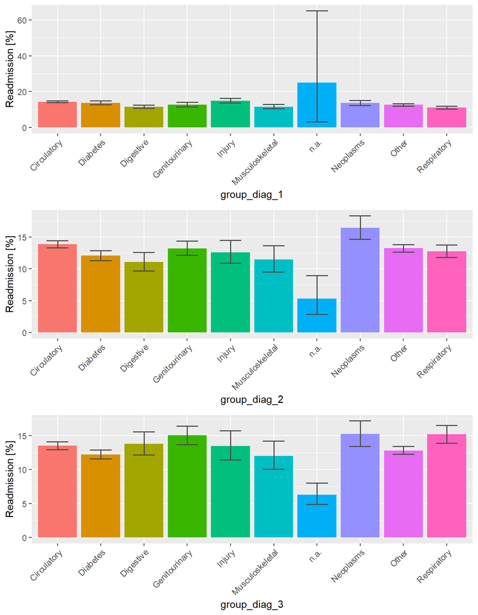

Fig. 23

```r
p1 <- plot_admission_by_category(diabetic_data_bin, "group_diag_1")
p2 <- plot_admission_by_category(diabetic_data_bin, "group_diag_2")
p3 <- plot_admission_by_category(diabetic_data_bin, "group_diag_3")

layout <- matrix(c(1, 2, 3), 3, 1, byrow = TRUE)
multiplot(p1, p2, p3, layout = layout)
```

## 4.4 d) 6 Multi-feature comparisons

Create a correlation matrix similar to Section 6.1 of the template. Discuss the key insights, especially with regard to their relevance for predicting the target variable.

**Solution:**

After studying each feature individually we will now start to look at *interactions* between them.

### 4.4.1 Correlation overview

We begin with a correlation matrix plot as a first comprehensive overview of our multi-parameter space. We will then take this overview plot as a starting point to investigate specific multi-feature comparisons in the following. Those examinations will likely result in more questions, which we can also examine (to a certain extend) in the same step.

What we will see here is the correlation coefficients for each combination of two features. In simplest terms: this shows whether two features are connected so that one changes with a predictable trend if you change the other. The closer this coefficient is to zero the weaker is the correlation. Both 1 and -1 are the ideal cases of perfect correlation and anti-correlation.

Here we will only include those features that we found to be useful in the previous step. Thereby, our plot will be easier to read and more informative. Note that for the purpose of this plot we will recode our factor features as integers.

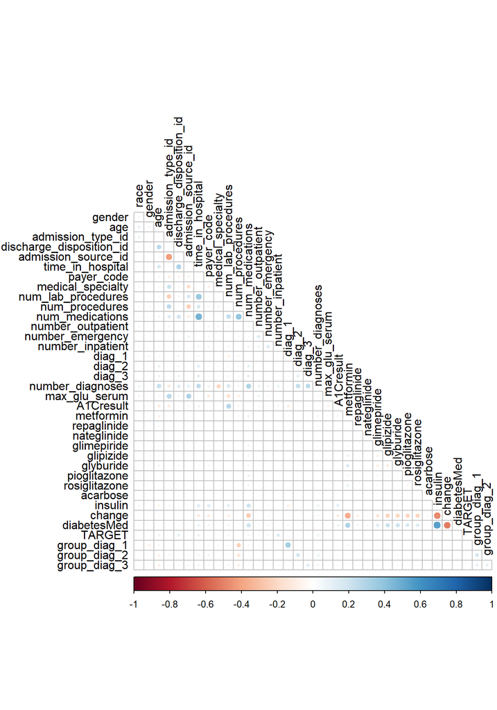

Fig. 24

```r
diabetic_data_bin %>%
  select(-weight,
         -acetohexamide, -troglitazone, -examide, -citoglipton,
         -`glipizide-metformin`, -`glimepiride-pioglitazone`, -`metformin-rosiglitazone`, -`metformin-pioglitazone`,
         -chlorpropamide, -tolbutamide, -miglitol, -tolazamide, -`glyburide-metformin`) %>%
  mutate(across(where(is.factor), ~ as.integer(.))) %>%
  cor(use = "complete.obs", method = "spearman") %>%
  corrplot(type = "lower", tl.col = "black", diag = FALSE)
```

In this kind of plot we want to look for the bright, large circles which immediately show the strong correlations (size and shading depends on the absolute values of the coefficients; colour depends on direction). Anything that you would have to squint to see is usually not worth seeing.

Key insights:

- Most features appear to have low pairwise correlations, indicating a lack of multicollinearity. This is helpful when building predictive models like logistic regression or tree-based classifiers.
- There is no obvious correlation with the TARGET feature. This could be caused by the sparsity of the `target == 1` values. Since no single variable shows a strong linear relationship with readmission, a multivariate approach (e.g., decision trees, ensemble methods) is more appropriate than relying on linear models or univariate thresholds.
- Some features appear to be primarily correlated with others in their group, such as those within the group “patient utilization history”.

Here we plot only the moderately to highly correlated features by showing their correlation coefficients directly:

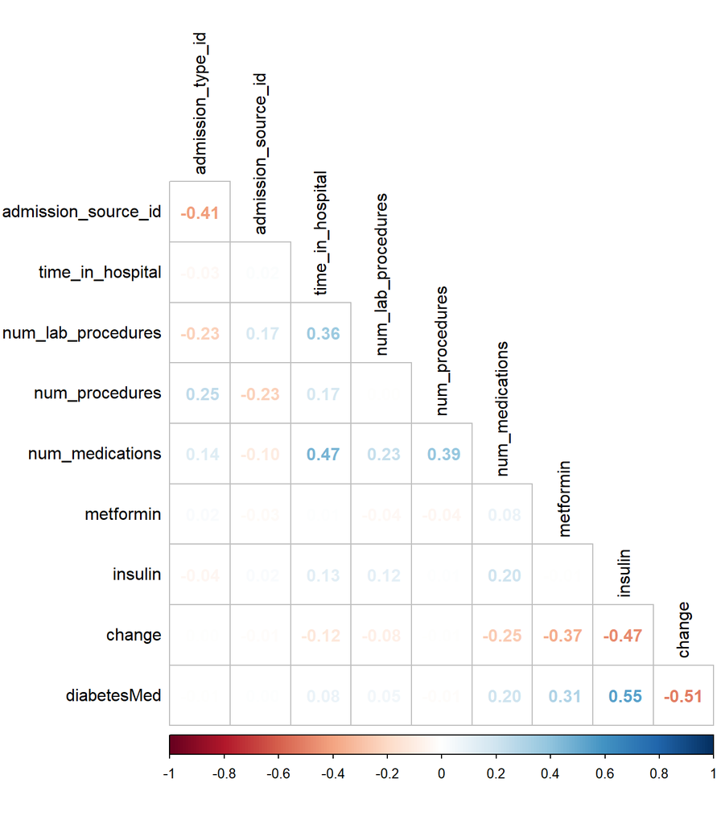

Fig. 25

```r
diabetic_data_bin %>%
  select(admission_type_id, admission_source_id,
         time_in_hospital, num_lab_procedures, num_procedures, num_medications,
         # number_diagnoses, max_glu_serum, A1Cresult, group_diag_1,
         metformin, insulin,
         change, diabetesMed) %>%
  mutate(across(where(is.factor), ~ as.integer(.))) %>%
  cor(use = "complete.obs", method = "spearman") %>%
  corrplot(type = "lower", tl.col = "black", diag = FALSE, method = "number")
```

Key insights:

- There is a strong correlation of 0.55 between `insulin` and `diabetesMed`; Other correlations that exist are weaker but still notable.
- Some anti-correlations exist as well, with *change* and `diabetesMed` accounting for the strongest coefficient with -0.51.
- Furthermore, some features, for example *num_procedures*, which showed only a small effect in the individual plots, exhibits correlation with other significant features, the fact of which might be interesting.

### 4.4.2 Exploring correlated features

Now we will have a closer look at those features we find to be correlated. Here our visualisation will depend on the feature group and how strong the relationship is.

#### 4.4.2.1 Pairwise relationships

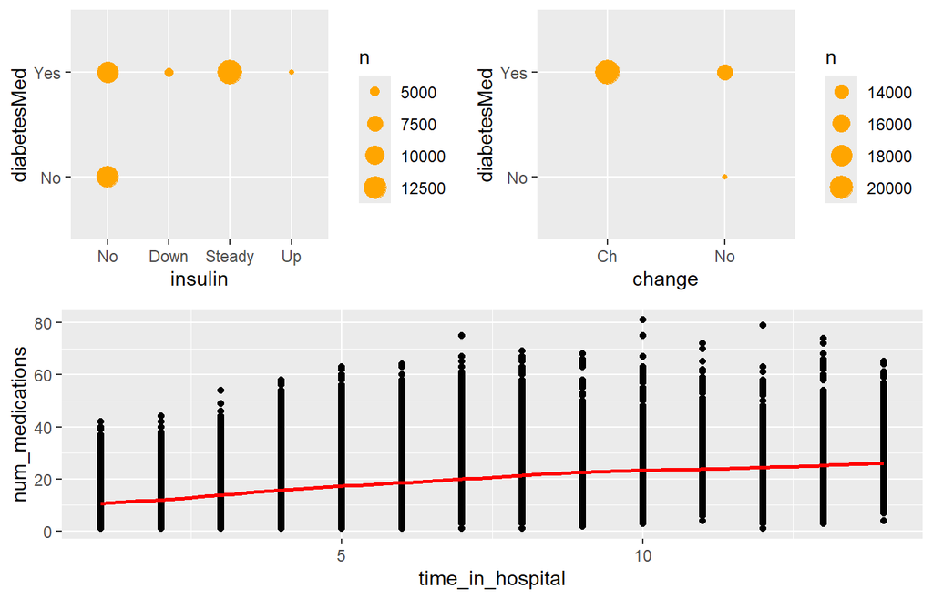

Fig. 26

```r
p1 <- diabetic_data_bin %>%
  ggplot(aes(insulin, diabetesMed)) +
  geom_count(color = "orange")

p2 <- diabetic_data_bin %>%
  ggplot(aes(change, diabetesMed)) +
  geom_count(color = "orange")

p3 <- diabetic_data_bin %>%
  ggplot(aes(time_in_hospital, num_medications)) +
  geom_point() +
  geom_smooth(method = 'gam', color = "red")

layout <- matrix(c(1, 2, 3, 3), 2, 2,byrow = TRUE)
multiplot(p1, p2, p3, layout = layout)
```

```r
# Remove all plots at the end
rm(p1, p2, p3, p4, p5, p6, p7, p8, p9, p10, p11, p12, p13, p14, p15, p16)
```

# 5 Task R3: Data Splitting and XGBoost

In this task, you will split the two datasets `diabetic_data_bin` (for binary classification) and `diabetic_data_ter` (for ternary classification) into training, validation, and test datasets for subsequent modeling and apply a first machine learning model with XGBoost for binary classification. Starting from subtask R3b), code snippets from the SWoF template must be extracted and modified in certain places. The goal of these modifications is to ensure that the code runs with minimal adjustments, using the training, validation, and test datasets prepared in subtask R3a) as input. For this and all subsequent tasks related to binary classification, the “area under the ROC curve” (AUC) is to be used as the evaluation metric for machine learning models. At the beginning of each relevant subtask, the corresponding section of the SWoF template is indicated in bold.

## 5.1 a) Data Splitting

Split the two datasets `diabetic_data_bin` and `diabetic_data_ter` into training, validation, and test datasets in a 70:15:15 ratio. Ensure that the target variable TARGET is correctly stratified during the splitting process to maintain class distribution. Output the number of rows in the training, validation, and test datasets, as well as the class proportions in each subsets.

**Solution:**

To split the datasets with a 70:15:15 ratio, while stratifying based on the TARGET variable, we use the function `createDataPartition` from the `caret` package for stratified sampling.

```r
split_data <- function(dat) {
  # Step 1: Initial 70% training split stratified on TARGET
  train_index <- createDataPartition(dat$TARGET, times = 1, p = 0.7, list = FALSE)
  train <- dat[train_index, ]
  temp <- dat[-train_index, ]

  # Step 2: Split remaining 30% into 15% validation and 15% test (i.e., 50:50 of remaining data)
  valid_index <- createDataPartition(temp$TARGET, times = 1, p = 0.5, list = FALSE)
  valid <- temp[valid_index, ]
  test <- temp[-valid_index, ]

  list(train = train,
       valid = valid,
       test = test)
}

# split the datasets `diabetic_data_bin` and `diabetic_data_ter`
diabetic_data_bin_splitted <- split_data(diabetic_data_bin)
diabetic_data_ter_splitted <- split_data(diabetic_data_ter)

rm(diabetic_data_bin, diabetic_data_ter)
```

```r
# Function to output number of rows as well as the class proportions
output_data_splitted <- function(data_splitted) {
  cat("\n\nRows in training set:", nrow(data_splitted$train), "\n")
  cat("Class proportions in training set (%):\n")
  print(round(100 * prop.table(table(data_splitted$train$TARGET)), 2))

  cat("\n\nRows in validation set:", nrow(data_splitted$valid), "\n")
  cat("Class proportions in validation set (%):\n")
  print(round(100 * prop.table(table(data_splitted$valid$TARGET)), 2))

  cat("\n\nRows in test set:", nrow(data_splitted$test), "\n")
  cat("Class proportions in test set (%):\n")
  print(round(100 * prop.table(table(data_splitted$test$TARGET)), 2))
}
```

```r
# Output for the dataset `diabetic_data_bin`
cat("Dataset:", "diabetic_data_bin")
```

```
## Dataset: diabetic_data_bin
```

```r
output_data_splitted(diabetic_data_bin_splitted)
```

```
##
##
## Rows in training set: 33426
## Class proportions in training set (%):
##
##     0     1
## 86.85 13.15
##
##
## Rows in validation set: 7163
## Class proportions in validation set (%):
##
##     0     1
## 86.85 13.15
##
##
## Rows in test set: 7162
## Class proportions in test set (%):
##
##     0     1
## 86.86 13.14
```

```r
# Output for the dataset `diabetic_data_bin`
cat("Dataset:", "diabetic_data_ter")
```

```
## Dataset: diabetic_data_ter
```

```r
output_data_splitted(diabetic_data_ter_splitted)
```

```
##
##
## Rows in training set: 48982
## Class proportions in training set (%):
##
##    NO   <30   >30
## 59.27  8.97 31.76
##
##
## Rows in validation set: 10496
## Class proportions in validation set (%):
##
##    NO   <30   >30
## 59.27  8.97 31.75
##
##
## Rows in test set: 10495
## Class proportions in test set (%):
##
##    NO   <30   >30
## 59.28  8.97 31.76
```

In the following, we assume our training, validation, as well as test data sets to be similar in the distributions of their features, i.e. the split appears to be well executed and stratified by feature levels as well.

## 5.2 b) 8.3 XGBoost parameters and fitting

Use the code from the indicated section of the template and ensure that it runs correctly. Adjust the code and parameters where necessary and appropriate to properly train the XGBoost model. Briefly discuss the role of the hyperparameters `colsample_bytree`, `subsample`, `max_depth`, and `eta` in the context of XGBoost, and compute the AUC score on the test dataset.

**Solution:**

#### 5.2.0.1 Step 1: Prepare the data

In order for *XGBoost* to properly ingest our data samples we need to re-format them slightly:

```r
# Feature formatting
process_data_for_xgboost <- function(dat) {
  dat_x <- dat %>%
    mutate(across(where(is.factor), ~ as.integer(.))) %>%
    select(-TARGET)
  dat_x <- as.matrix(dat_x)

  # Encode TARGET as 0, 1, ...
  dat_y <- as.integer(dat$TARGET) - 1

  return(list(dat_x = dat_x, dat_y = dat_y))
}

xgb_train <- process_data_for_xgboost(diabetic_data_bin_splitted$train)
xgb_valid <- process_data_for_xgboost(diabetic_data_bin_splitted$valid)
xgb_test <- process_data_for_xgboost(diabetic_data_bin_splitted$test)

dtrain <- xgb.DMatrix(xgb_train$dat_x,label = xgb_train$dat_y)
dvalid <- xgb.DMatrix(xgb_valid$dat_x,label = xgb_valid$dat_y)
dtest <- xgb.DMatrix(xgb_test$dat_x)
```

#### 5.2.0.2 Step 2: Define hyperparameter grid

Key XGBoost hyperparameters that govern how *XGBoost* operates explained:

- `colsample_bytree`: Controls the fraction of features (columns) to be randomly sampled when constructing each tree. Subsampling occurs once for every tree constructed. Values range in (0, 1]. Lower values can help prevent overfitting by introducing feature randomness.
- `subsample`: Denotes the fraction of the training instances to be randomly sampled once every boosting iteration. Values range in (0, 1]. By adding randomness to the training process, subsampling can prevent overfitting.
- `max_depth`: Sets the maximum depth of a tree. Deeper trees can model more complex relationships but may overfit the data. Typical values range from 3 to 10.
- `eta`: Controls the step size shrinkage used in updates to prevent overfitting, the so-called learning rate. Lower values make the model more robust to overfitting but require more boosting rounds. Typical values range from 0.01 to 0.3.

We now specify the grid of hyperparameters to search over. Note that this step is commented out in subsequent runs after identifying the best parameters in the initial run, in order to save compilation time when knitting the report to HTML.

```r
# # Define hyperparameter grid
# xgb_grid <- expand.grid(
#   colsample_bytree = c(0.6, 0.8, 1.0),
#   subsample = c(0.6, 0.8, 1.0),
#   max_depth = c(3, 5, 7),
#   eta = c(0.01, 0.1, 0.5)
# )
```

#### 5.2.0.3 Step 3: Perform cross-validation

For each combination of hyperparameters, we use `xgb.cv` to perform a cross-validation (CV) step to measure our model’s performance.

We are using a 5-fold CV, which essentially means that we split our data in 5 parts and train on any 4 of them while evaluating on the remaining one. This is done iteratively, so that every fold becomes the validation fold. This is an efficient way to measure the performance of your fit on data it has not seen.

Again, this step is commented out in subsequent runs after identifying the best parameters in the initial run, in order to save compilation time when knitting the report to HTML.

```r
# # Initialize progress bar and set the seed anew
# pb <- txtProgressBar(min = 0, max = nrow(xgb_grid), style = 3)
# set.seed(seed)
#
# # Loop over each combination of hyperparameters
# for (i in 1:nrow(xgb_grid)) {
#   # Set XGBoost parameters
#   xgb_params <- list(colsample_bytree = xgb_grid$colsample_bytree[i], # variables per tree
#                      subsample = xgb_grid$subsample[i], # data subset per tree
#                      booster = "gbtree",
#                      max_depth = xgb_grid$max_depth[i], # tree levels
#                      eta = xgb_grid$eta[i], # shrinkage
#                      eval_metric = "auc",
#                      objective = "reg:logistic"
#                      )
#
#   xgb_cv <- xgb.cv(xgb_params,
#                    dtrain,
#                    nrounds = 120,
#                    nfold = 5,
#                    verbose = FALSE,
#                    early_stopping_rounds = 5,
#                    maximize = TRUE)
#
#   # Get the auc score
#   xgb_grid$auc[i] <- max(xgb_cv$evaluation_log$test_auc_mean)
#
#   # Update progress bar
#   setTxtProgressBar(pb, i)
# }
#
# # Close progress bar
# close(pb)
#
# best_params <- xgb_grid[which.max(xgb_grid$auc), ]
```

#### 5.2.0.4 Step 4: Train the final model

Having found the best parameters and features during cross-validation, we can now train our classifier.

```r
# The best hyperparameters found in the initial run
best_params <- data.frame(colsample_bytree = 0.6,
                          subsample = 0.8,
                          max_depth = 5,
                          eta = 0.1)

# Set XGBoost parameters
xgb_params <- list(colsample_bytree = best_params$colsample_bytree, # variables per tree
                   subsample = best_params$subsample, # data subset per tree
                   booster = "gbtree",
                   max_depth = best_params$max_depth, # tree levels
                   eta = best_params$eta, # shrinkage
                   eval_metric = "auc",
                   objective = "reg:logistic",
                   nthread = 1
                   )

# Define watchlist to monitor training and validation error
watchlist <- list(train = dtrain, valid = dvalid)

# Train the XGBoost with the best parameter found
set.seed(seed)
xgb <- xgb.train(params = xgb_params,
                 data = dtrain,
                 print_every_n = 5,
                 watchlist = watchlist,
                 nrounds = 120,
                 maximize = TRUE,
                 early_stopping_rounds = 5)
```

[output not shown]

Be aware that this is not a competitive model. Other (engineered) features can be included, the meta-parameters can be optimised, and a larger amount of training steps can be run. In addition, several kernels have already shown the power of ensembling different individual models into a combined prediction that shows better results.

What this basic model can do is to serve as an example on how to construct your own prediction and give you a place to start from. Make sure to check out other modelling kernels as well to get a broader overview.

#### 5.2.0.5 Step 5: Evaluate the model on the test set

Once we are reasonably happy with our model, we use it to predict and compute the AUC on the test dataset:

```r
# Predict probabilities on the test set
xgb_probs <- predict(xgb, newdata = dtest)

# Compute AUC using MLmetrics
auc_xgb <- AUC(y_pred = xgb_probs, y_true = xgb_test$dat_y)

# Output the AUC score
cat("Test AUC (XGBoost):", auc_xgb, "\n")
```

```
## Test AUC (XGBoost): 0.7030061
```

## 5.3 c) 8.4 Feature importance

Compute the feature importances of the XGBoost model just trained and visualize them using an appropriate plot. Identify the most important features and provide a brief qualitative discussion on why they may be relevant for predicting readmissions (no specific knowledge of health insurance or healthcare is required). Finally, briefly outline the potential implications of these findings for model development, predictive performance, and the design of preventive insurance strategies.

**Solution:**

After training we will check which features are the most important for our model. This can provide the starting point for an iterative process where we identify, step by step, the significant features for a model. Here we will simply visualise these features:

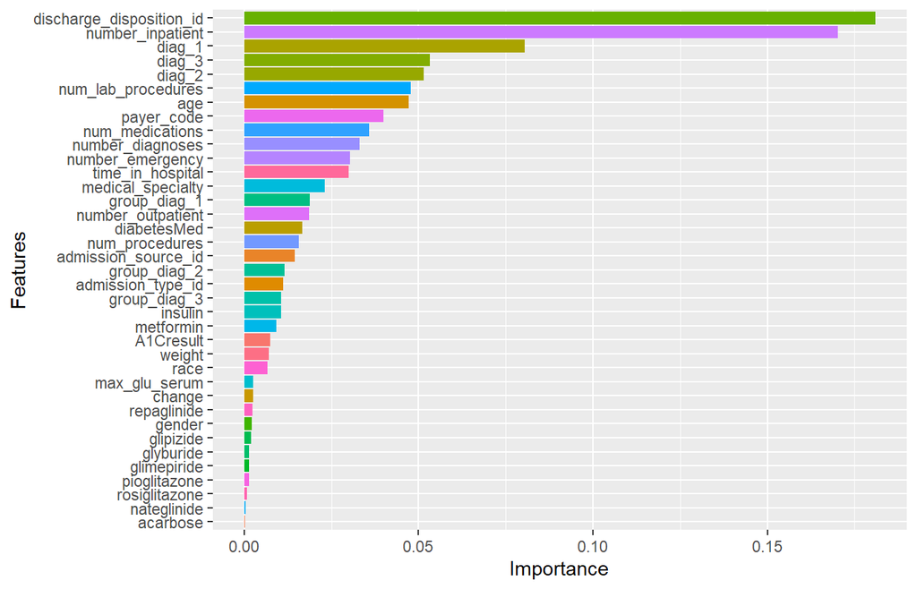

Fig. 27

```r
imp_matrix <- as.tibble(xgb.importance(feature_names = colnames(xgb_train$dat_x),
                                       model = xgb))

imp_matrix %>%
  ggplot(aes(reorder(Feature, Gain, FUN = max), Gain, fill = Feature)) +
  geom_col() +
  coord_flip() +
  theme(legend.position = "none") +
  labs(x = "Features", y = "Importance")
```

##### 5.3.0.0.1 Feature importance insights

Based on the feature importance plot, the following variables emerged as the most significant predictors of readmission, along with the rationale behind their relevance:

**Implications for model development**:

- Feature selection:
  - The dominance of a few features suggests that a smaller, more interpretable model could yield comparable performance to more complex alternatives.
  - Features with very low importance (e.g., some rarely used medications) can be excluded to reduce overfitting and computational load.
- Custom feature engineering:
  - Grouping similar categorical values (e.g., discharge codes or diagnosis categories) based on clinical relevance or statistical behavior can enhance generalization.
  - Interaction features such as `age × number_inpatient` or `diag_1 × discharge_disposition` may help uncover non-linear effects and improve prediction.
- Handling of categorical variables:
  - For high-cardinality categorical variables like `discharge_disposition_id`, consider advanced encoding methods, such as embeddings, to preserve predictive signal without overfitting.

**Implications for predictive performance**:

- Improved AUC: Focusing on top-ranked predictors helps the model better distinguish between readmitted and non-readmitted patients, improving classification metrics such as AUC.
- Better Generalization: Models built on robust, clinically meaningful features, such as `number_inpatient` and `diag_1`, are more likely to perform well on unseen data.

**Implications for preventive insurance strategies**:

- Targeted Interventions: Use high-risk indicators to proactively identify patients who may benefit from enhanced post-discharge support, such as follow-up calls, home visits, or disease management programs.
- Personalized risk-based plans: Leverage the model outputs to design patient-specific wellness or insurance plans, aligning resources with individual risk profiles to reduce preventable readmissions and associated costs.

In the following, we will consistently use the package `caret` via its advantage as a uniform interface for streamlining the process for creating predictive models.

# 6 Task R4: Logistic Regressions Without and With Interactions

Following the examination of an XGBoost model for binary classification in Task R3, this task focuses on Logistic Regression. Both a Logistic Regression without interactions and a model with interactions will be explored. The training and test datasets prepared in subtask R3a) serve as input data.

## 6.1 a) Logistic Regression Without Interactions

Train a basic Logistic Regression that uses all relevant predictors (without interactions). Select only features that have at least two distinct values, and exclude the target variable as well as the diagnosis columns (`diag_1`, `diag_2`, `diag_3`). Briefly discuss, in four to five bullet points, the key insights derived from the coefficients of the resulting Logistic Regression. Compute the AUC score of this model on the test dataset and output the result. Generate and visualize a confusion matrix that compares the model’s predictions with the actual values in the test dataset. Before constructing the confusion matrix, briefly discuss the challenges of choosing an appropriate threshold, particularly in balancing sensitivity and specificity. Then, use a threshold of 0.2 to generate the matrix.

**Solution:**

In the following, we will use consistently the package `caret` for its advantage as a unique interface to streamline the process for creating predictive models and keep the entire workflow in a single, consistent framework.

#### 6.1.0.1 Step 1: Setup and preprocessing

```r
# Perform feature selection
feature_selection <- function(dat) {
  # Exclude features with a unique value
  dat %>%
    select(-acetohexamide, -troglitazone, -examide, -citoglipton,
           -`glipizide-metformin`, -`glimepiride-pioglitazone`,
           -`metformin-rosiglitazone`, -`metformin-pioglitazone`) %>%
    select(-starts_with("diag_"))
}

train <- feature_selection(diabetic_data_bin_splitted$train)
valid <- feature_selection(diabetic_data_bin_splitted$valid)
test <- feature_selection(diabetic_data_bin_splitted$test)

# Recode levels to "X0" and "X1" as caret expects two-level factors with proper names
levels(train$TARGET) <- make.names(levels(train$TARGET))
levels(valid$TARGET) <- make.names(levels(valid$TARGET))
levels(test$TARGET) <- make.names(levels(test$TARGET))
```

#### 6.1.0.2 Step 2: Train the logistic regression model on training dataset

We use the training set to fit the model and, in general, the validation set to select the best model parameters. While standard logistic regression does not have tunable hyperparameters (thus a validation set is not strictly necessary), regularized versions (e.g., Lasso or Ridge regression) introduce penalty terms that require parameter tuning — which we explore later.

```r
# Set up train control without resampling (since validation is separate)
# `twoClassSummary` assumes that the second factor level is the positive class
ctrl <- trainControl(
  method = "none", # No cross-validation
  classProbs = TRUE, # Needed to compute probabilities for ROC
  summaryFunction = twoClassSummary # To use AUC
  # verboseIter = TRUE
)

# Train logistic regression on training set
set.seed(seed)
logit <- train(
  TARGET ~ .,
  data = train,
  method = "glm",
  family = "binomial",
  trControl = ctrl,
  metric = "ROC"
)
```

```r
# Print model summary
summary(logit)
```

```
##
## Call:
## NULL
##
## Coefficients:
##                                                           Estimate Std. Error
## (Intercept)                                             -7.431e+00  1.460e+02
## raceAfricanAmerican                                      1.733e-01  1.161e-01
## raceAsian                                               -2.995e-01  2.371e-01
## raceCaucasian                                            1.359e-01  1.100e-01
## raceHispanic                                             1.756e-01  1.588e-01
## raceOther                                               -2.063e-01  1.823e-01
## genderMale                                              -4.763e-02  3.479e-02
## age.L                                                    2.758e-01  4.102e-01
## age.Q                                                   -2.781e-01  4.089e-01
## age.C                                                   -5.394e-02  3.532e-01
## `age^4`                                                 -2.809e-01  2.790e-01
## `age^5`                                                 -2.688e-02  2.110e-01
## `age^6`                                                  4.620e-02  1.566e-01
## `age^7`                                                  2.220e-02  1.164e-01
## `age^8`                                                  3.384e-02  8.783e-02
## `age^9`                                                 -1.875e-01  6.310e-02
## weight.L                                                -7.770e-01  5.940e-01
## weight.Q                                                 4.815e-02  3.939e-01
## weight.C                                                -4.824e-01  5.089e-01
## `weight^4`                                               1.097e+00  6.596e-01
## `weight^5`                                              -1.595e-01  6.236e-01
## `weight^6`                                               1.489e-01  4.581e-01
## `weight^7`                                               6.429e-02  2.574e-01
## admission_type_id2                                       1.195e-01  6.838e-02
## admission_type_id3                                      -1.543e-02  7.952e-02
## admission_type_id5                                       2.037e-01  1.206e-01
## admission_type_id6                                       4.664e-01  9.749e-02
## admission_type_id7                                      -1.370e+01  3.744e+02
## admission_type_id8                                      -3.905e-01  3.050e-01
## discharge_disposition_id2                                5.952e-01  9.913e-02
## discharge_disposition_id3                                5.798e-01  5.465e-02
## discharge_disposition_id4                                3.132e-01  1.818e-01
## discharge_disposition_id5                                1.301e+00  1.110e-01
## discharge_disposition_id6                                2.446e-01  5.657e-02
```

[output cut: 340 more lines]

```
## group_diag_3Musculoskeletal                              -0.631 0.528161
## group_diag_3n.a.                                         -0.209 0.834142
## group_diag_3Neoplasms                                    -0.033 0.973942
## group_diag_3Other                                        -1.489 0.136583
## group_diag_3Respiratory                                   1.005 0.314700
## ---
## Signif. codes:  0 '***' 0.001 '**' 0.01 '*' 0.05 '.' 0.1 ' ' 1
##
## (Dispersion parameter for binomial family taken to be 1)
##
##     Null deviance: 26015  on 33425  degrees of freedom
## Residual deviance: 23930  on 33237  degrees of freedom
## AIC: 24308
##
## Number of Fisher Scoring iterations: 14
```

Based on the coefficients and significance levels in the logistic regression output for predicting hospital readmission, here are the key insights:

- **Hospitalization history and inpatient count are strong predictors**: The variable `number_inpatient` has a very significant positive coefficient (p < 2e-16), suggesting that a higher number of prior inpatient visits is strongly associated with increased likelihood of readmission.
- **Certain discharge dispositions greatly influence readmission risk**: Dispositions like `discharge_disposition_id3`, `id5`, and `id22` are highly significant (p < 0.001) with large positive or negative coefficients, indicating they are critical predictors. For example, `id2` likely corresponds to patients discharged to another facility, which increases readmission risk.
- **Some medical specialties reduce readmission odds**: Specialties like *Orthopedics-Reconstructive* and *ObstetricsandGynecology* show negative and significant coefficients, suggesting patients under their care have a lower probability of being readmitted.
- **Diabetes medication usage impacts readmission**: The variable `diabetesMedYes` is statistically significant, indicating that diabetes management plays a notable role in predicting readmission.
- **Diagnosis groups vary in predictive power**: Group primary diagnosis indicators such as `group_diag_1Respiratory` are highly significant and negatively associated with readmission, highlighting the differing risk profiles across disease categories. With the exception of `group_diag_2Diabetes`, all secondary and tertiary diagnosis groups are not statistically significant at the 5% level.

```r
# Predict probabilities
log_probs <- predict(logit, newdata = test, type = "prob")[, "X1"]

# Compute AUC
auc_log <- AUC(y_pred = log_probs, y_true = as.numeric(test$TARGET) - 1)
cat("Test AUC (Logistic Regression):", auc_log, "\n")
```

```
## Test AUC (Logistic Regression): 0.685818
```

**Threshold Selection in Classification Models**

In binary classification problems like predicting hospital readmission, the model outputs probabilities. To convert these into class predictions, we apply a threshold, usually 0.5 by default. But this may not always be ideal.

Challenges in choosing a threshold:

- Imbalanced data: If one class (e.g., readmitted patients) is rare, a threshold of 0.5 might miss many true positives.
- Sensitivity vs. specificity:
  - A lower threshold (e.g., 0.2) increases sensitivity (true positive rate) but may also increase false positives.
  - A higher threshold increases specificity but may miss actual cases.
- Use-case dependency: In healthcare, missing a high-risk patient (false negative) can be more costly than a false positive, motivating the use of a lower threshold.

We use now a threshold of 0.2 to generate the confusion matrix.

```r
# Apply custom threshold and relabel back the levels of the TARGET
threshold <- 0.2
pred_classes <- factor(ifelse(log_probs > threshold, "1", "0"), levels = c("1", "0"))
actual_classes <- factor(test$TARGET, levels = c("X1", "X0"), labels = c("1", "0"))

# Create confusion matrix
conf_matrix <- confusionMatrix(pred_classes, actual_classes)

# Print confusion matrix
print(conf_matrix)
```

```
## Confusion Matrix and Statistics
##
##           Reference
## Prediction    1    0
##          1  299  727
##          0  642 5494
##
##                Accuracy : 0.8089
##                  95% CI : (0.7996, 0.8179)
##     No Information Rate : 0.8686
##     P-Value [Acc > NIR] : 1.00000
##
##                   Kappa : 0.1935
##
##  Mcnemar's Test P-Value : 0.02319
##
##             Sensitivity : 0.31775
##             Specificity : 0.88314
##          Pos Pred Value : 0.29142
##          Neg Pred Value : 0.89537
##              Prevalence : 0.13139
##          Detection Rate : 0.04175
##    Detection Prevalence : 0.14326
##       Balanced Accuracy : 0.60044
##
##        'Positive' Class : 1
##
```

We then visualize the confusion matrix using a simple `geom_tile` plot for clarity and interpretability.

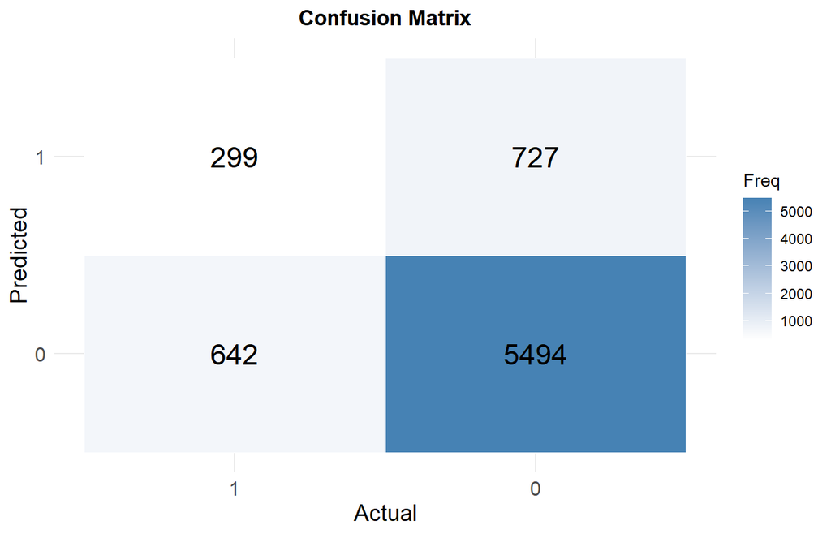

Fig. 28

```r
# Visualize confusion matrix
visualize_cm <- function(conf_matrix) {
  # Convert the table to a data frame for plotting
  cm_df <- as.data.frame(conf_matrix$table)

  # Make sure the levels are ordered so "1" comes first in both axes
  cm_df$Reference <- factor(cm_df$Reference, levels = c("1", "0"))
  cm_df$Prediction <- factor(cm_df$Prediction, levels = c("0", "1"))

  # Plot
  ggplot(data = cm_df, aes(x = Reference, y = Prediction, fill = Freq)) +
    geom_tile(color = "white") +
    geom_text(aes(label = Freq), size = 6) +
    scale_fill_gradient(low = "white", high = "steelblue") +
    labs(
      title = "Confusion Matrix",
      x = "Actual",
      y = "Predicted") +
    theme_minimal() +
    theme(
      plot.title = element_text(hjust = 0.5, face = "bold"),
      axis.text = element_text(size = 12),
      axis.title = element_text(size = 14))
}

visualize_cm(conf_matrix)
```

## 6.2 b) Logistic Regression With Interactions

Use, for example, the `hstats` package to identify interactions between the predictors of the XGBoost model from Task R3. Briefly explain in a few sentences how these interactions are detected. Select the three most significant interactions that do not involve `diag_1`, `diag_2`, or `diag_3`, and incorporate these interactions into the Logistic Regression from subtask R4a) by extending the regression formula accordingly. Train this enhanced model on the training dataset, compute its AUC score on the test dataset, and output the result. Generate and visualize a confusion matrix, analogous to subtask R4a).

**Solution:**

The `hstats` package detects interactions using H-statistics, which measure how much **the effect of one variable depends on another** in the model’s predictions. Specifically, it compares the model’s **joint prediction function** for two variables with the **sum of their individual effects**. If the joint effect differs significantly from the sum of individual effects, the variables are said to interact. An H-statistic close to 1 indicates a strong interaction, while a value near 0 suggests little to no interaction.

```r
# Compute H-statistics for interaction effects
# here the seed set for the sampling of training data
set.seed(seed)
suppressMessages(
  suppressWarnings(
    h_interactions <- hstats(
      object = xgb,
      X = xgb_train$dat_x,
      fun = predict,
      type = "interaction",
      n_max = 5000, # About 10 % of the training data
    )))
```

[output not shown]

```r
# Print interaction summary
print(h_interactions)
```

```
## 'hstats' object. Use plot() or summary() for details.
##
## H^2 (normalized)
## [1] 0.1515852
```

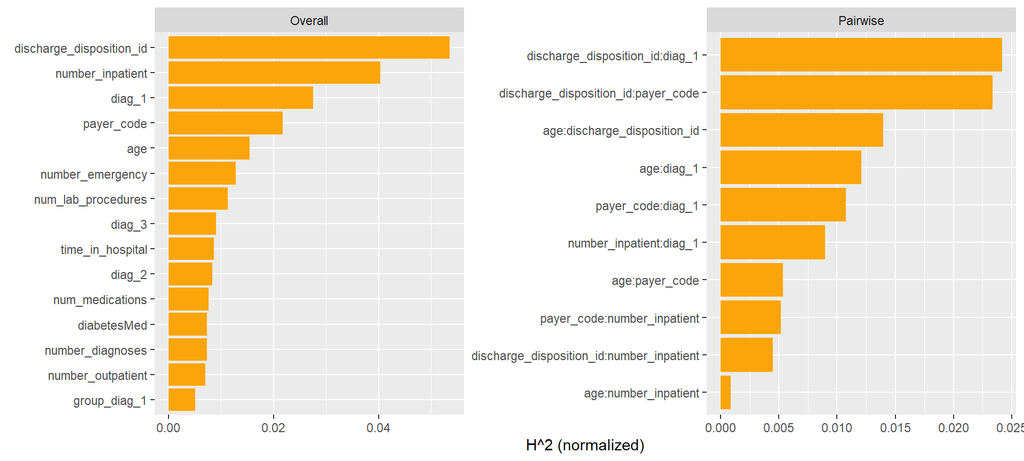

Fig. 29

```r
# Plot top interactions
plot(h_interactions)
```

This shows pairwise interaction strengths for your predictors. The higher the value (closer to 1), the stronger the interaction between those variables.

To check whether interactions generalize well, we compute interaction structure on the test dataset to assess stability.

```r
# Compute H-statistics on test datasets
suppressMessages(
  suppressWarnings(
    h_interactions <- hstats(
      object = xgb,
      X = xgb_test$dat_x,
      fun = predict,
      type = "interaction",
      n_max = nrow(xgb_test$dat_x),
    )))
```

[output not shown]

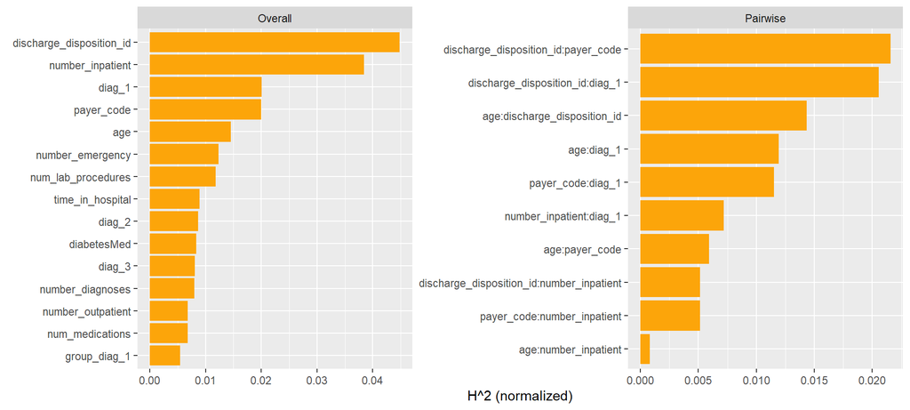

Fig. 30

```r
# Plot top interactions
plot(h_interactions)
```

```r
# Step 1: Define the formula with three desired interactions
formula <- TARGET ~ . + admission_type_id:number_inpatient +
    discharge_disposition_id:number_inpatient +
    admission_type_id:time_in_hospital

# Step 2: Build design matrix
mm <- model.matrix(formula, data = train)

# Step 3: Find and remove linearly dependent columns
lc <- findLinearCombos(mm)

if (length(lc$remove) > 0) {
  mm_clean <- mm[, -lc$remove]
} else {
  mm_clean <- mm
}
rm(mm)

# Step 4: Fit the logistic regression model using caret
set.seed(seed)
logit_with_interaction <- train(
  x = mm_clean[, -1],
  y = train$TARGET,
  method = "glm",
  family = "binomial",
  trControl = ctrl,
  metric = "ROC"
)
# Print model summary
summary(logit_with_interaction)
```

```
##
## Call:
## NULL
##
## Coefficients:
##                                                           Estimate Std. Error
## (Intercept)                                             -7.640e+00  1.416e+02
## raceAfricanAmerican                                      1.713e-01  1.160e-01
## raceAsian                                               -2.787e-01  2.365e-01
## raceCaucasian                                            1.378e-01  1.099e-01
## raceHispanic                                             1.805e-01  1.589e-01
## raceOther                                               -1.986e-01  1.823e-01
## genderMale                                              -4.820e-02  3.484e-02
## age.L                                                    2.456e-01  4.109e-01
## age.Q                                                   -2.618e-01  4.093e-01
## age.C                                                   -9.276e-02  3.536e-01
## `age^4`                                                 -2.668e-01  2.794e-01
## `age^5`                                                 -3.690e-02  2.115e-01
## `age^6`                                                  4.503e-02  1.572e-01
## `age^7`                                                  2.345e-02  1.170e-01
## `age^8`                                                  2.901e-02  8.836e-02
## `age^9`                                                 -1.856e-01  6.340e-02
## weight.L                                                -7.889e-01  5.950e-01
## weight.Q                                                 5.121e-02  3.957e-01
## weight.C                                                -4.816e-01  5.090e-01
## `weight^4`                                               1.074e+00  6.594e-01
## `weight^5`                                              -1.361e-01  6.228e-01
## `weight^6`                                               1.680e-01  4.565e-01
## `weight^7`                                               8.144e-02  2.563e-01
## admission_type_id2                                       2.653e-01  9.911e-02
## admission_type_id3                                       1.125e-01  1.073e-01
## admission_type_id5                                       3.217e-01  1.728e-01
## admission_type_id6                                       4.999e-01  1.527e-01
## admission_type_id7                                      -1.280e+01  9.505e+02
## admission_type_id8                                      -1.583e-01  4.503e-01
## discharge_disposition_id2                                5.087e-01  1.099e-01
## discharge_disposition_id3                                6.518e-01  5.785e-02
## discharge_disposition_id4                                3.905e-01  1.931e-01
## discharge_disposition_id5                                1.380e+00  1.176e-01
## discharge_disposition_id6                                3.104e-01  6.010e-02
```

[output cut: 390 more lines]

```
## `admission_type_id3:time_in_hospital`                    -1.977 0.047998 *
## `admission_type_id5:time_in_hospital`                    -0.829 0.407117
## `admission_type_id6:time_in_hospital`                    -0.789 0.430262
## `admission_type_id7:time_in_hospital`                    -0.001 0.999180
## `admission_type_id8:time_in_hospital`                    -1.120 0.262554
## ---
## Signif. codes:  0 '***' 0.001 '**' 0.01 '*' 0.05 '.' 0.1 ' ' 1
##
## (Dispersion parameter for binomial family taken to be 1)
##
##     Null deviance: 26015  on 33425  degrees of freedom
## Residual deviance: 23882  on 33212  degrees of freedom
## AIC: 24310
##
## Number of Fisher Scoring iterations: 14
```

We compute then the AUC score on the test dataset converted to its associated model matrix.

```r
mm_test <- model.matrix(formula, data = test)[, -lc$remove]

# Predict probabilities
log_with_int_probs <- predict(logit_with_interaction, newdata = mm_test, type = "prob")[, "X1"]

# Compute AUC
auc_log_with_int <- AUC(y_pred = log_with_int_probs, y_true = as.numeric(test$TARGET) - 1)
cat("Test AUC (Logistic Regression with Interactions):", auc_log_with_int, "\n")
```

```
## Test AUC (Logistic Regression with Interactions): 0.6852429
```

```r
# Apply custom threshold and relabel back the levels of the TARGET
threshold <- 0.2
pred_classes <- factor(ifelse(log_probs > threshold, "1", "0"), levels = c("1", "0"))
actual_classes <- factor(test$TARGET, levels = c("X1", "X0"), labels = c("1", "0"))

# Create confusion matrix
conf_matrix <- confusionMatrix(pred_classes, actual_classes, positive = "1")
```

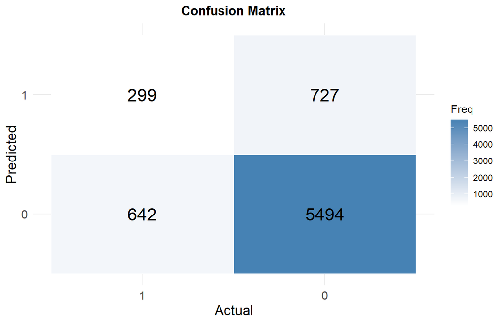

Fig. 31

```r
# Visualize confusion matrix
visualize_cm(conf_matrix)
```

```r
# Print confusion matrix
print(conf_matrix)
```

```
## Confusion Matrix and Statistics
##
##           Reference
## Prediction    1    0
##          1  299  727
##          0  642 5494
##
##                Accuracy : 0.8089
##                  95% CI : (0.7996, 0.8179)
##     No Information Rate : 0.8686
##     P-Value [Acc > NIR] : 1.00000
##
##                   Kappa : 0.1935
##
##  Mcnemar's Test P-Value : 0.02319
##
##             Sensitivity : 0.31775
##             Specificity : 0.88314
##          Pos Pred Value : 0.29142
##          Neg Pred Value : 0.89537
##              Prevalence : 0.13139
##          Detection Rate : 0.04175
##    Detection Prevalence : 0.14326
##       Balanced Accuracy : 0.60044
##
##        'Positive' Class : 1
##
```

## 6.3 c) Model Comparison and Discussion:

Compare the results of the Logistic Regressions without and with interactions. Discuss whether including interactions led to a significant improvement in model performance. Additionally, briefly discuss three approaches to integrating interactions differently or more effectively to further improve model quality.

**Solution:**

**Three approaches to integrate interactions more effectively**:

1. **Data-driven interaction discovery**: Use algorithms (e.g., hstats) to identify only the most informative interactions, those that contribute significant mutual dependence with the outcome, instead of including all possible pairs.
2. **Feature engineering based on domain knowledge**: Instead of adding all pairwise interactions, construct specific, meaningful combinations grounded in clinical reasoning. For example, `discharge_disposition_id * time_in_hospital` may capture complexity around post-discharge care. This promotes interpretability and robustness.
3. **Nonlinear models or hybrid approaches**: When logistic regression fails to capture complex dependencies, consider simple nonlinear models such as Generalized Additive Models (GAMs), which allow for smooth, nonlinear effects and interactions.

# 7 Task R5: Regularized Linear Models and GAMs

In this task, you will apply regularized linear models (L1 and L2 regularization) as well as Generalized Additive Models (GAMs) for modelling. The training and test datasets prepared in subtask R3a) will serve as input data. In all subtasks, use the same set of predictors as in subtask R4a).

## 7.1 a) L1 Regularization (LASSO)

Apply the LASSO method (L1 regularization) to the training data. Determine the optimal regularization parameter $λ$ using cross-validation, visualize the regularization path, and output all non-zero coefficients. Briefly discuss three possible relationships between the non-zero coefficients of the LASSO model and the insights gained from the EDA in Task R2. Compute the AUC score of the model on the test data.

**Solution:**

Note that we can use `caret` to train a L1-regularized linear model as follows:

```r
# Set tuning grid for LASSO (alpha = 1 corresponds to LASSO; alpha = 0 would be Ridge)
tune_grid <- expand.grid(
  alpha = 1,                                 # Use LASSO regularization
  lambda = 10^seq(-10, 0, length.out = 100)  # Logarithmic grid of λ values
)

# Set up train control with 5-fold cross validation
ctrl <- trainControl(
  method = "cv", # cross-validation
  number = 5,
  classProbs = TRUE, # Needed to compute probabilities for ROC
  summaryFunction = twoClassSummary # To use AUC
)

# Train LASSO model using caret
set.seed(seed)
lasso <- train(
  TARGET ~ .,
  data = train,
  method = "glmnet",
  trControl = ctrl,
  metric = "ROC",
  tuneGrid = tune_grid
)
```

However, `caret` does not provide a direct way to plot the LASSO regularization path like `plot(fit_glmnet, xvar = "lambda")` does, we hereby switch to using `glmnet` instead. Furthermore, we don’t have to specify the range of lambda to search over.

#### 7.1.0.1 Step 1: Prepare the data matrices

Since `glmnet` requires a numeric model matrix, some preprocessing is necessary.

```r
# Create model matrices (exclude intercept)
mm_train <- model.matrix(TARGET ~ ., train)[, -1]
mm_valid <- model.matrix(TARGET ~ ., valid)[, -1]
mm_test <- model.matrix(TARGET ~ ., test)[, -1]
```

#### 7.1.0.2 Step 2: Apply LASSO with cross-validation

We determine the optimal regularization parameter $λ$ using cross-validation.

```r
# Hyperparameter tuning for LASSO via cross-validation
set.seed(seed)
cv_lasso <- cv.glmnet(
  x = mm_train,
  y = train$TARGET,
  family = "binomial",
  alpha = 1, # LASSO
  type.measure = "auc" # AUC as evaluation metric
  # nfolds = 10
)
```

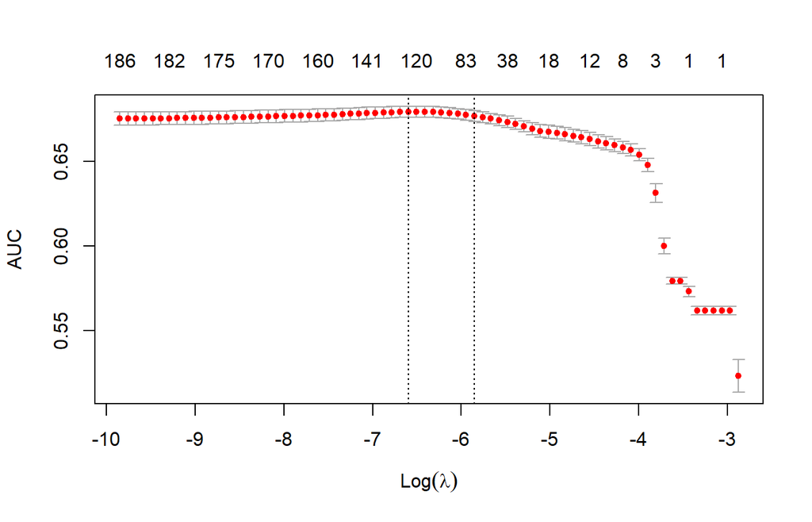

Fig. 32

```r
# Visualise cross-validated AUC vs. log(lambda)
plot(cv_lasso)
```

```r
# Optimal regularization paramter λ
best_lambda <- cv_lasso$lambda.min
cat("Optimal regularization paramter λ:", best_lambda, "\n")
```

```
## Optimal regularization paramter λ: 0.001363397
```